# MEA Analysis James Crowe

David Colameo

2024-10-28

## Load Libraries and useful functions

```r
library(dplyr)
library(stringr)
library(ggplot2)
library(lmerTest)
library(emmeans)


##agregation function
ag <- function(df, cols, fun=mean) {
  c <- colnames(df[,unlist(lapply(df, is.numeric))])
  print(c)
  df <- aggregate(df[,c], by=as.list(df[,cols]), FUN=fun)
  return(df[, colSums(is.na(df)) != nrow(df)])
}
```

## Load Data and clean-up Burst Analysis Data

Change path to folder with excel files generated by the python script. They can be inside subfolders as the function searches them recursively.

- This chunk of code extracts information from the path of the recordings. Make sure, the organisation is the same or change organisation accordingly.
- You can find the description on how to do it below:
- To facilitate the workflow later on with other tables, I created a function which can be applied to any table containing this structure of information within the path

### The function repeated over the whole workflow

Read comments to understand on how to adapt to new paths

```r
clean_table_mea <- function(df.ag){
split_path <- function(x) if (dirname(x)==x) x else c(basename(x),split_path(dirname(x)))

##Extract the filename from path

## the index inside square brackets decides which part of the path will be
## extracted.
## Here the [1] is the file name, [2] would be set ect.
## "C:\\Users\\James\\Desktop\\Jupyter\\SET1\\2023-11-24T14-53-19_E15_SP_WT3_PTX_N+A.h5"
df.ag$FileName <- sapply(df.ag$File, function(x){
  split_path(x)[1]
})


## this chunk extracts the set name from the path, see above
df.ag$Set <- sapply(df.ag$column_label, function(x){
  split_path(x)[2]

})

## Add more columns by copy pasting the chunk above and adapting the square bracket index
## to the element of path you want to extract


#################################################################################
### Extract information from the original recording filename
#################################################################################

## this chunk of code splits the file name by the character "_" and takes the
## first element which in this case is the date of recording

df.ag$Date <- sapply(df.ag$FileName, function(x){
  unlist(str_split(x, "_"))[1]
})

## Same with E13-15
df.ag$E.No <- sapply(df.ag$FileName, function(x){
  unlist(str_split(x, "_"))[2]
})

df.ag$Genotype <- sapply(df.ag$FileName, function(x){
  unlist(str_split(x, "_"))[3]
})

df.ag$Brainregion <- sapply(df.ag$FileName, function(x){
  unlist(str_split(x, "_"))[4]
})

#############
### Add more chunks from above if you want to extract more information from path
#############


### Condition needed to have "N+A" added
df.ag$Condition <- sapply(df.ag$FileName, function(x){
  unlist(str_split(x, "_"))[5]
})

df.ag$Condition <- ifelse(df.ag$Condition == "PTX", "PTX_N+A", df.ag$Condition)
df.ag$Condition <- sapply(df.ag$Condition, function(x){
  unlist(str_split(x, "\\."))[1]
})


#############
#### in some instances, genotype and brainregion was mixed up, so I corrected it here
#############
unique(df.ag$Genotype)

df.ag$Genotype2 <- sapply(df.ag$FileName, function(x){
  unlist(str_split(x, "_"))[4]
})

df.ag$Genotype <- ifelse(df.ag$Genotype %in% c("WT3", "KO",  "GD1", "I9"), df.ag$Genotype, df.ag$Genotype2)
df.ag$Brainregion <- ifelse(grepl("SP", df.ag$FileName), "SP", NA)
df.ag$Brainregion <- ifelse(grepl("CTX", df.ag$FileName), "CTX", df.ag$Brainregion)
df.ag$Genotype <- ifelse(grepl("WT", df.ag$Genotype), "WT", df.ag$Genotype)

## Create a unique experimental ID from Set and genotype
df.ag$Exp_ID <- paste(df.ag$Set, df.ag$Genotype, df.ag$Brainregion, sep=".")
df.ag
}
```

```r
##change path here
wd_path <- "C:\\Users\\davec\\Documents\\R-Markdowns\\MEA_James\\MEA"

l_files <- list.files(path = wd_path ,pattern = "*.xlsx$", recursive = TRUE, full.names = TRUE)
l_files <- l_files[!grepl("SET", l_files) & !grepl("Jupyter", l_files) & !grepl("~", l_files)]

dfs <- lapply(l_files, function(x){
  as.data.frame(readxl::read_xlsx(x, sheet="Burst Level Analysis"))
})
names(dfs) <- l_files

df <- bind_rows(dfs, .id = "column_label")

#df <- df[df$Burst_Peak_frequency > 1,]

df.ag <- ag(df, cols= c("column_label", "File"))
```

```
##  [1] "...1"                 "burst_index"          "burst_frame"
##  [4] "burst_time_s"         "event_window_start"   "event_window_end"
##  [7] "Burst_Peak_frequency" "width_ms"             "inst_freq"
## [10] "isi_s"                "area"
```

```r
df.burst <- clean_table_mea(df.ag)
df.burst.single <- clean_table_mea(df)
```

## Plot Burst Results and Statistics

You can plot whichever numeric parameter from the burst table by changing the column you want to have displayed

- here I plotted the Burst_peak_frequency which shows how many units are participating in a burst
- isi_s is another interesting metric which is related to the frequency of burst over the whole recording

Since the recordings have a rather high variabilty, I plotted them as log-transformed values

Statistics: I opted for a linear mixed model (lmer), which is similar to a two-way anova. The difference is, that the model takes into account the repeated measurements (baseline, PTX and PTX+NA). Furthermore, it has far fewer assumptions as an ANOVA.

I separated WT and KO from I9 and GD9. Here, you have decide which statistical design makes most sense, as I dont have the full biological background to judge for it.

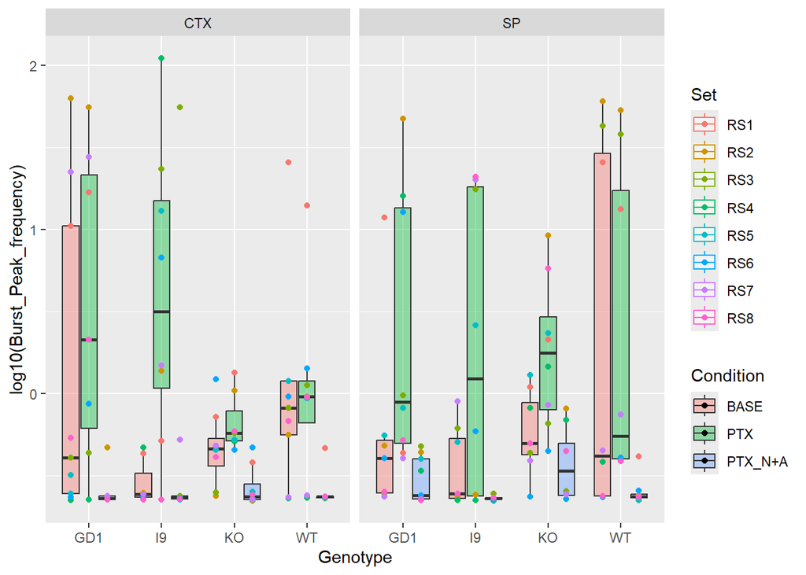

```r
ggplot(df.burst, aes(x=Genotype, y=log10(Burst_Peak_frequency), color=Set, fill=Condition, group=interaction(Genotype, Condition))) + geom_boxplot(alpha=0.4) + geom_point(position=position_jitterdodge(0)) + facet_grid(.~Brainregion, scales="free")
```

```r
df.burst$Genotype <- factor(df.burst$Genotype, levels= c("WT", "KO", "I9", "GD1"))

mod <- lmer(log10(Burst_Peak_frequency) ~ Genotype * Condition * Brainregion + (1|Exp_ID), subset(df.burst, Genotype %in% c("WT", "KO")))
summary(mod)
```

```
## Linear mixed model fit by REML. t-tests use Satterthwaite's method [
## lmerModLmerTest]
## Formula: log10(Burst_Peak_frequency) ~ Genotype * Condition * Brainregion +
##     (1 | Exp_ID)
##    Data: subset(df.burst, Genotype %in% c("WT", "KO"))
##
## REML criterion at convergence: 136.5
##
## Scaled residuals:
##      Min       1Q   Median       3Q      Max
## -2.13522 -0.52766 -0.02484  0.36345  2.09279
##
## Random effects:
##  Groups   Name        Variance Std.Dev.
##  Exp_ID   (Intercept) 0.1583   0.3978
##  Residual             0.1312   0.3622
## Number of obs: 97, groups:  Exp_ID, 32
##
## Fixed effects:
##                                           Estimate Std. Error       df t value
## (Intercept)                                0.02702    0.18619 49.87193   0.145
## GenotypeKO                                -0.35812    0.26618 51.60228  -1.345
## ConditionPTX                              -0.02317    0.17687 57.87631  -0.131
## ConditionPTX_N+A                          -0.62281    0.17275 58.20564  -3.605
## BrainregionSP                              0.24539    0.26618 51.60228   0.922
## GenotypeKO:ConditionPTX                    0.17505    0.25933 58.26117   0.675
## GenotypeKO:ConditionPTX_N+A                0.38656    0.25028 57.90017   1.545
## GenotypeKO:BrainregionSP                  -0.15527    0.37844 52.45574  -0.410
## ConditionPTX:BrainregionSP                 0.08878    0.25314 57.74652   0.351
## ConditionPTX_N+A:BrainregionSP            -0.24561    0.25028 57.90017  -0.981
## GenotypeKO:ConditionPTX:BrainregionSP      0.24996    0.36449 57.94561   0.686
## GenotypeKO:ConditionPTX_N+A:BrainregionSP  0.29339    0.35810 57.75824   0.819
##                                           Pr(>|t|)
## (Intercept)                               0.885193
## GenotypeKO                                0.184380
## ConditionPTX                              0.896225
## ConditionPTX_N+A                          0.000648 ***
## BrainregionSP                             0.360879
## GenotypeKO:ConditionPTX                   0.502352
## GenotypeKO:ConditionPTX_N+A               0.127915
```

[output cut: 18 more lines]

```
## CPTX_N+A:BS    0.320 -0.224 -0.337 -0.690    -0.470  0.230     0.476
## GKO:CPTX:BS   -0.219  0.322  0.485  0.237     0.322 -0.711    -0.343
## GKO:CPTX_N+A: -0.224  0.329  0.236  0.482     0.329 -0.337    -0.699
##               GKO:BS CPTX:B CPTX_N+A: GKO:CPTX:
## GenotypeKO
## ConditinPTX
## CndtPTX_N+A
## BrainregnSP
## GntyKO:CPTX
## GnKO:CPTX_N+A
## GntypKO:BSP
## CndtPTX:BSP    0.327
## CPTX_N+A:BS    0.331  0.494
## GKO:CPTX:BS   -0.465 -0.695 -0.343
## GKO:CPTX_N+A: -0.473 -0.345 -0.699     0.491
```

```r
emmeans(mod, trt.vs.ctrl ~ Condition | Genotype | Brainregion, ref="BASE")
```

```
## $emmeans
## Genotype = WT, Brainregion = CTX:
##  Condition   emmean    SE   df lower.CL upper.CL
##  BASE       0.02702 0.186 49.2  -0.3472   0.4012
##  PTX        0.00385 0.190 52.6  -0.3777   0.3854
##  PTX_N+A   -0.59578 0.186 49.2  -0.9700  -0.2216
##
## Genotype = KO, Brainregion = CTX:
##  Condition   emmean    SE   df lower.CL upper.CL
##  BASE      -0.33109 0.190 52.6  -0.7127   0.0505
##  PTX       -0.17922 0.199 58.1  -0.5766   0.2182
##  PTX_N+A   -0.56734 0.190 52.6  -0.9489  -0.1858
##
## Genotype = WT, Brainregion = SP:
##  Condition   emmean    SE   df lower.CL upper.CL
##  BASE       0.27241 0.190 52.6  -0.1092   0.6540
##  PTX        0.33802 0.190 52.6  -0.0436   0.7196
##  PTX_N+A   -0.59600 0.190 52.6  -0.9776  -0.2144
##
## Genotype = KO, Brainregion = SP:
##  Condition   emmean    SE   df lower.CL upper.CL
##  BASE      -0.24098 0.190 52.6  -0.6226   0.1406
##  PTX        0.24963 0.190 52.6  -0.1320   0.6312
##  PTX_N+A   -0.42945 0.190 52.6  -0.8110  -0.0479
##
## Degrees-of-freedom method: kenward-roger
## Results are given on the log10 (not the response) scale.
## Confidence level used: 0.95
##
## $contrasts
## Genotype = WT, Brainregion = CTX:
##  contrast         estimate    SE   df t.ratio p.value
##  PTX - BASE        -0.0232 0.177 57.3  -0.131  0.9810
##  (PTX_N+A) - BASE  -0.6228 0.173 57.6  -3.603  0.0013
##
## Genotype = KO, Brainregion = CTX:
##  contrast         estimate    SE   df t.ratio p.value
##  PTX - BASE         0.1519 0.190 58.0   0.800  0.6367
##  (PTX_N+A) - BASE  -0.2362 0.181 57.0  -1.304  0.3347
##
## Genotype = WT, Brainregion = SP:
##  contrast         estimate    SE   df t.ratio p.value
##  PTX - BASE         0.0656 0.181 57.0   0.362  0.8956
##  (PTX_N+A) - BASE  -0.8684 0.181 57.0  -4.795  <.0001
##
## Genotype = KO, Brainregion = SP:
##  contrast         estimate    SE   df t.ratio p.value
##  PTX - BASE         0.4906 0.181 57.0   2.709  0.0172
##  (PTX_N+A) - BASE  -0.1885 0.181 57.0  -1.041  0.4838
##
## Degrees-of-freedom method: kenward-roger
## Results are given on the log10 (not the response) scale.
## P value adjustment: dunnettx method for 2 tests
```

```r
emmeans(mod, trt.vs.ctrl ~ Genotype | Condition | Brainregion, ref="WT")
```

```
## $emmeans
## Condition = BASE, Brainregion = CTX:
##  Genotype   emmean    SE   df lower.CL upper.CL
##  WT        0.02702 0.186 49.2  -0.3472   0.4012
##  KO       -0.33109 0.190 52.6  -0.7127   0.0505
##
## Condition = PTX, Brainregion = CTX:
##  Genotype   emmean    SE   df lower.CL upper.CL
##  WT        0.00385 0.190 52.6  -0.3777   0.3854
##  KO       -0.17922 0.199 58.1  -0.5766   0.2182
##
## Condition = PTX_N+A, Brainregion = CTX:
##  Genotype   emmean    SE   df lower.CL upper.CL
##  WT       -0.59578 0.186 49.2  -0.9700  -0.2216
##  KO       -0.56734 0.190 52.6  -0.9489  -0.1858
##
## Condition = BASE, Brainregion = SP:
##  Genotype   emmean    SE   df lower.CL upper.CL
##  WT        0.27241 0.190 52.6  -0.1092   0.6540
##  KO       -0.24098 0.190 52.6  -0.6226   0.1406
##
## Condition = PTX, Brainregion = SP:
##  Genotype   emmean    SE   df lower.CL upper.CL
##  WT        0.33802 0.190 52.6  -0.0436   0.7196
##  KO        0.24963 0.190 52.6  -0.1320   0.6312
##
## Condition = PTX_N+A, Brainregion = SP:
##  Genotype   emmean    SE   df lower.CL upper.CL
##  WT       -0.59600 0.190 52.6  -0.9776  -0.2144
##  KO       -0.42945 0.190 52.6  -0.8110  -0.0479
##
## Degrees-of-freedom method: kenward-roger
## Results are given on the log10 (not the response) scale.
## Confidence level used: 0.95
##
## $contrasts
## Condition = BASE, Brainregion = CTX:
##  contrast estimate    SE   df t.ratio p.value
##  KO - WT   -0.3581 0.266 50.9  -1.345  0.1845
##
## Condition = PTX, Brainregion = CTX:
##  contrast estimate    SE   df t.ratio p.value
##  KO - WT   -0.1831 0.275 55.4  -0.666  0.5083
##
## Condition = PTX_N+A, Brainregion = CTX:
##  contrast estimate    SE   df t.ratio p.value
##  KO - WT    0.0284 0.266 50.9   0.107  0.9153
##
## Condition = BASE, Brainregion = SP:
##  contrast estimate    SE   df t.ratio p.value
##  KO - WT   -0.5134 0.269 52.6  -1.908  0.0618
##
## Condition = PTX, Brainregion = SP:
##  contrast estimate    SE   df t.ratio p.value
##  KO - WT   -0.0884 0.269 52.6  -0.329  0.7438
##
## Condition = PTX_N+A, Brainregion = SP:
##  contrast estimate    SE   df t.ratio p.value
##  KO - WT    0.1666 0.269 52.6   0.619  0.5385
##
## Degrees-of-freedom method: kenward-roger
## Results are given on the log10 (not the response) scale.
```

```r
mod <- lmer(log10(Burst_Peak_frequency) ~ Genotype * Condition * Brainregion + (1|Exp_ID), subset(df.burst, Genotype %in% c("I9", "GD1")))
summary(mod)
```

```
## Linear mixed model fit by REML. t-tests use Satterthwaite's method [
## lmerModLmerTest]
## Formula: log10(Burst_Peak_frequency) ~ Genotype * Condition * Brainregion +
##     (1 | Exp_ID)
##    Data: subset(df.burst, Genotype %in% c("I9", "GD1"))
##
## REML criterion at convergence: 190.5
##
## Scaled residuals:
##      Min       1Q   Median       3Q      Max
## -1.66137 -0.53664 -0.09848  0.33967  2.91050
##
## Random effects:
##  Groups   Name        Variance Std.Dev.
##  Exp_ID   (Intercept) 0.1116   0.3341
##  Residual             0.3338   0.5778
## Number of obs: 96, groups:  Exp_ID, 32
##
## Fixed effects:
##                                            Estimate Std. Error       df t value
## (Intercept)                                -0.48187    0.25036 77.98461  -1.925
## GenotypeGD1                                 0.63497    0.33816 74.12524   1.878
## ConditionPTX                                1.07349    0.30076 57.13343   3.569
## ConditionPTX_N+A                            0.10040    0.29674 60.19734   0.338
## BrainregionSP                               0.01953    0.34404 76.33821   0.057
## GenotypeGD1:ConditionPTX                   -0.73634    0.42250 58.63791  -1.743
## GenotypeGD1:ConditionPTX_N+A               -0.85195    0.40927 58.53588  -2.082
## GenotypeGD1:BrainregionSP                  -0.39903    0.48241 75.27365  -0.827
## ConditionPTX:BrainregionSP                 -0.34263    0.41703 56.48707  -0.822
## ConditionPTX_N+A:BrainregionSP             -0.27404    0.41414 58.03686  -0.662
## GenotypeGD1:ConditionPTX:BrainregionSP      0.58904    0.59365 57.57237   0.992
## GenotypeGD1:ConditionPTX_N+A:BrainregionSP  0.71129    0.58225 58.28322   1.222
##                                            Pr(>|t|)
## (Intercept)                                0.057912 .
## GenotypeGD1                                0.064353 .
## ConditionPTX                               0.000734 ***
## ConditionPTX_N+A                           0.736282
## BrainregionSP                              0.954872
## GenotypeGD1:ConditionPTX                   0.086608 .
## GenotypeGD1:ConditionPTX_N+A               0.041759 *
```

[output cut: 18 more lines]

```
## CPTX_N+A:BS     0.478 -0.354 -0.398 -0.717    -0.641  0.283      0.519
## GGD1:CPTX:B    -0.328  0.435  0.507  0.281     0.443 -0.712     -0.362
## GGD1:CPTX_N+A: -0.340  0.443  0.283  0.510     0.456 -0.358     -0.703
##                GGD1:B CPTX:B CPTX_N+A: GGD1:CPTX:
## GenotypeGD1
## ConditinPTX
## CndtPTX_N+A
## BrainregnSP
## GntGD1:CPTX
## GnGD1:CPTX_N+A
## GntyGD1:BSP
## CndtPTX:BSP     0.450
## CPTX_N+A:BS     0.457  0.528
## GGD1:CPTX:B    -0.621 -0.702 -0.371
## GGD1:CPTX_N+A: -0.636 -0.376 -0.711     0.519
```

```r
emmeans(mod, trt.vs.ctrl ~ Condition | Genotype | Brainregion, ref="BASE")
```

```
## $emmeans
## Genotype = I9, Brainregion = CTX:
##  Condition emmean    SE   df lower.CL upper.CL
##  BASE      -0.482 0.251 78.0 -0.98117  0.01743
##  PTX        0.592 0.236 74.4  0.12148  1.06177
##  PTX_N+A   -0.381 0.228 68.9 -0.83556  0.07262
##
## Genotype = GD1, Brainregion = CTX:
##  Condition emmean    SE   df lower.CL upper.CL
##  BASE       0.153 0.228 68.9 -0.30098  0.60719
##  PTX        0.490 0.251 78.0 -0.00905  0.98956
##  PTX_N+A   -0.598 0.236 74.4 -1.06859 -0.12830
##
## Genotype = I9, Brainregion = SP:
##  Condition emmean    SE   df lower.CL upper.CL
##  BASE      -0.462 0.236 74.4 -0.93248  0.00781
##  PTX        0.269 0.236 74.4 -0.20162  0.73867
##  PTX_N+A   -0.636 0.236 74.4 -1.10612 -0.16583
##
## Genotype = GD1, Brainregion = SP:
##  Condition emmean    SE   df lower.CL upper.CL
##  BASE      -0.226 0.251 78.0 -0.72570  0.27290
##  PTX        0.357 0.236 74.4 -0.11299  0.82731
##  PTX_N+A   -0.541 0.228 68.9 -0.99478 -0.08661
##
## Degrees-of-freedom method: kenward-roger
## Results are given on the log10 (not the response) scale.
## Confidence level used: 0.95
##
## $contrasts
## Genotype = I9, Brainregion = CTX:
##  contrast         estimate    SE   df t.ratio p.value
##  PTX - BASE          1.073 0.301 57.3   3.565  0.0015
##  (PTX_N+A) - BASE    0.100 0.298 60.4   0.337  0.9073
##
## Genotype = GD1, Brainregion = CTX:
##  contrast         estimate    SE   df t.ratio p.value
##  PTX - BASE          0.337 0.298 60.4   1.132  0.4290
##  (PTX_N+A) - BASE   -0.752 0.282 56.9  -2.664  0.0193
##
## Genotype = I9, Brainregion = SP:
##  contrast         estimate    SE   df t.ratio p.value
##  PTX - BASE          0.731 0.289 56.0   2.530  0.0273
##  (PTX_N+A) - BASE   -0.174 0.289 56.0  -0.601  0.7634
##
## Genotype = GD1, Brainregion = SP:
##  contrast         estimate    SE   df t.ratio p.value
##  PTX - BASE          0.584 0.301 57.3   1.938  0.1063
##  (PTX_N+A) - BASE   -0.314 0.298 60.4  -1.055  0.4748
##
## Degrees-of-freedom method: kenward-roger
## Results are given on the log10 (not the response) scale.
## P value adjustment: dunnettx method for 2 tests
```

```r
emmeans(mod, trt.vs.ctrl ~ Genotype | Condition | Brainregion, ref="I9")
```

```
## $emmeans
## Condition = BASE, Brainregion = CTX:
##  Genotype emmean    SE   df lower.CL upper.CL
##  I9       -0.482 0.251 78.0 -0.98117  0.01743
##  GD1       0.153 0.228 68.9 -0.30098  0.60719
##
## Condition = PTX, Brainregion = CTX:
##  Genotype emmean    SE   df lower.CL upper.CL
##  I9        0.592 0.236 74.4  0.12148  1.06177
##  GD1       0.490 0.251 78.0 -0.00905  0.98956
##
## Condition = PTX_N+A, Brainregion = CTX:
##  Genotype emmean    SE   df lower.CL upper.CL
##  I9       -0.381 0.228 68.9 -0.83556  0.07262
##  GD1      -0.598 0.236 74.4 -1.06859 -0.12830
##
## Condition = BASE, Brainregion = SP:
##  Genotype emmean    SE   df lower.CL upper.CL
##  I9       -0.462 0.236 74.4 -0.93248  0.00781
##  GD1      -0.226 0.251 78.0 -0.72570  0.27290
##
## Condition = PTX, Brainregion = SP:
##  Genotype emmean    SE   df lower.CL upper.CL
##  I9        0.269 0.236 74.4 -0.20162  0.73867
##  GD1       0.357 0.236 74.4 -0.11299  0.82731
##
## Condition = PTX_N+A, Brainregion = SP:
##  Genotype emmean    SE   df lower.CL upper.CL
##  I9       -0.636 0.236 74.4 -1.10612 -0.16583
##  GD1      -0.541 0.228 68.9 -0.99478 -0.08661
##
## Degrees-of-freedom method: kenward-roger
## Results are given on the log10 (not the response) scale.
## Confidence level used: 0.95
##
## $contrasts
## Condition = BASE, Brainregion = CTX:
##  contrast estimate    SE   df t.ratio p.value
##  GD1 - I9   0.6350 0.339 74.2   1.875  0.0648
##
## Condition = PTX, Brainregion = CTX:
##  contrast estimate    SE   df t.ratio p.value
##  GD1 - I9  -0.1014 0.344 76.4  -0.294  0.7693
##
## Condition = PTX_N+A, Brainregion = CTX:
##  contrast estimate    SE   df t.ratio p.value
##  GD1 - I9  -0.2170 0.328 71.8  -0.662  0.5102
##
## Condition = BASE, Brainregion = SP:
##  contrast estimate    SE   df t.ratio p.value
##  GD1 - I9   0.2359 0.344 76.4   0.685  0.4953
##
## Condition = PTX, Brainregion = SP:
##  contrast estimate    SE   df t.ratio p.value
##  GD1 - I9   0.0886 0.334 74.4   0.266  0.7913
##
## Condition = PTX_N+A, Brainregion = SP:
##  contrast estimate    SE   df t.ratio p.value
##  GD1 - I9   0.0953 0.328 71.8   0.291  0.7722
##
## Degrees-of-freedom method: kenward-roger
## Results are given on the log10 (not the response) scale.
```

## Interspike Interval in seconds

see above

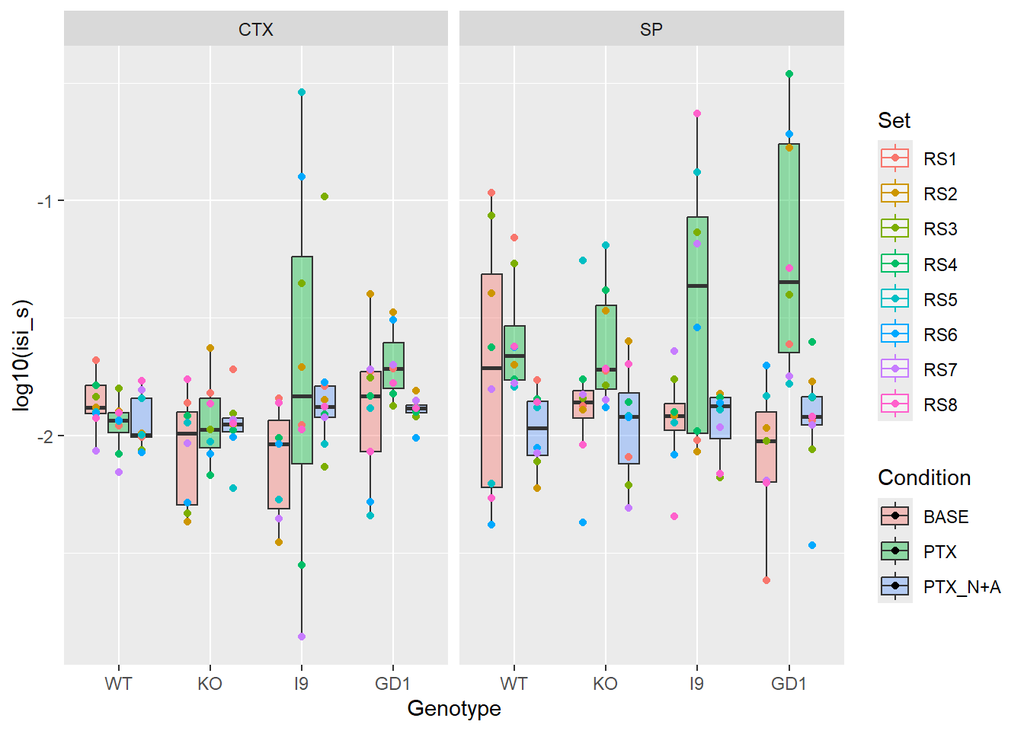

```r
ggplot(df.burst, aes(x=Genotype, y=log10(isi_s), color=Set, fill=Condition, group=interaction(Genotype, Condition))) + geom_boxplot(alpha=0.4) + geom_point(position=position_jitterdodge(0)) + facet_grid(.~Brainregion, scales="free")
```

```r
mod <- lmer(log10(isi_s) ~ Genotype * Condition * Brainregion + (1|Exp_ID), subset(df.burst, Genotype %in% c("WT", "KO")))
summary(mod)
```

```
## Linear mixed model fit by REML. t-tests use Satterthwaite's method [
## lmerModLmerTest]
## Formula: log10(isi_s) ~ Genotype * Condition * Brainregion + (1 | Exp_ID)
##    Data: subset(df.burst, Genotype %in% c("WT", "KO"))
##
## REML criterion at convergence: 24.9
##
## Scaled residuals:
##      Min       1Q   Median       3Q      Max
## -2.49474 -0.48492  0.00728  0.54322  2.41804
##
## Random effects:
##  Groups   Name        Variance Std.Dev.
##  Exp_ID   (Intercept) 0.01417  0.1191
##  Residual             0.04727  0.2174
## Number of obs: 97, groups:  Exp_ID, 32
##
## Fixed effects:
##                                           Estimate Std. Error       df t value
## (Intercept)                               -1.85617    0.08424 71.11953 -22.035
## GenotypeKO                                -0.20624    0.12156 73.96348  -1.697
## ConditionPTX                              -0.10240    0.10599 57.63900  -0.966
## ConditionPTX_N+A                          -0.09400    0.10328 58.61323  -0.910
## BrainregionSP                              0.14293    0.12156 73.96348   1.176
## GenotypeKO:ConditionPTX                    0.22939    0.15509 58.25099   1.479
## GenotypeKO:ConditionPTX_N+A                0.19759    0.14995 57.71946   1.318
## GenotypeKO:BrainregionSP                   0.06218    0.17361 75.24060   0.358
## ConditionPTX:BrainregionSP                 0.22763    0.15183 57.26881   1.499
## ConditionPTX_N+A:BrainregionSP            -0.16899    0.14995 57.71946  -1.127
## GenotypeKO:ConditionPTX:BrainregionSP     -0.12220    0.21838 57.58858  -0.560
## GenotypeKO:ConditionPTX_N+A:BrainregionSP -0.02776    0.21476 57.30805  -0.129
##                                           Pr(>|t|)
## (Intercept)                                 <2e-16 ***
## GenotypeKO                                   0.094 .
## ConditionPTX                                 0.338
## ConditionPTX_N+A                             0.366
## BrainregionSP                                0.243
## GenotypeKO:ConditionPTX                      0.145
## GenotypeKO:ConditionPTX_N+A                  0.193
## GenotypeKO:BrainregionSP                     0.721
```

[output cut: 17 more lines]

```
## CPTX_N+A:BS    0.422 -0.293 -0.336 -0.689    -0.617  0.229     0.474
## GKO:CPTX:BS   -0.289  0.423  0.485  0.236     0.423 -0.710    -0.343
## GKO:CPTX_N+A: -0.295  0.431  0.234  0.481     0.431 -0.338    -0.698
##               GKO:BS CPTX:B CPTX_N+A: GKO:CPTX:
## GenotypeKO
## ConditinPTX
## CndtPTX_N+A
## BrainregnSP
## GntyKO:CPTX
## GnKO:CPTX_N+A
## GntypKO:BSP
## CndtPTX:BSP    0.426
## CPTX_N+A:BS    0.432  0.494
## GKO:CPTX:BS   -0.608 -0.695 -0.343
## GKO:CPTX_N+A: -0.619 -0.345 -0.698     0.492
```

```r
emmeans(mod, trt.vs.ctrl ~ Condition | Genotype | Brainregion, ref="BASE")
```

```
## $emmeans
## Genotype = WT, Brainregion = CTX:
##  Condition emmean     SE   df lower.CL upper.CL
##  BASE       -1.86 0.0843 71.2    -2.02    -1.69
##  PTX        -1.96 0.0876 76.5    -2.13    -1.78
##  PTX_N+A    -1.95 0.0843 71.2    -2.12    -1.78
##
## Genotype = KO, Brainregion = CTX:
##  Condition emmean     SE   df lower.CL upper.CL
##  BASE       -2.06 0.0876 76.5    -2.24    -1.89
##  PTX        -1.94 0.0934 79.4    -2.12    -1.75
##  PTX_N+A    -1.96 0.0876 76.5    -2.13    -1.78
##
## Genotype = WT, Brainregion = SP:
##  Condition emmean     SE   df lower.CL upper.CL
##  BASE       -1.71 0.0876 76.5    -1.89    -1.54
##  PTX        -1.59 0.0876 76.5    -1.76    -1.41
##  PTX_N+A    -1.98 0.0876 76.5    -2.15    -1.80
##
## Genotype = KO, Brainregion = SP:
##  Condition emmean     SE   df lower.CL upper.CL
##  BASE       -1.86 0.0876 76.5    -2.03    -1.68
##  PTX        -1.62 0.0876 76.5    -1.80    -1.45
##  PTX_N+A    -1.95 0.0876 76.5    -2.12    -1.78
##
## Degrees-of-freedom method: kenward-roger
## Results are given on the log10 (not the response) scale.
## Confidence level used: 0.95
##
## $contrasts
## Genotype = WT, Brainregion = CTX:
##  contrast         estimate    SE   df t.ratio p.value
##  PTX - BASE        -0.1024 0.106 57.8  -0.965  0.5306
##  (PTX_N+A) - BASE  -0.0940 0.103 58.8  -0.908  0.5667
##
## Genotype = KO, Brainregion = CTX:
##  contrast         estimate    SE   df t.ratio p.value
##  PTX - BASE         0.1270 0.113 58.9   1.120  0.4360
##  (PTX_N+A) - BASE   0.1036 0.109 57.1   0.953  0.5385
##
## Genotype = WT, Brainregion = SP:
##  contrast         estimate    SE   df t.ratio p.value
##  PTX - BASE         0.1252 0.109 57.1   1.152  0.4176
##  (PTX_N+A) - BASE  -0.2630 0.109 57.1  -2.419  0.0358
##
## Genotype = KO, Brainregion = SP:
##  contrast         estimate    SE   df t.ratio p.value
##  PTX - BASE         0.2324 0.109 57.1   2.138  0.0691
##  (PTX_N+A) - BASE  -0.0932 0.109 57.1  -0.857  0.6001
##
## Degrees-of-freedom method: kenward-roger
## Results are given on the log10 (not the response) scale.
## P value adjustment: dunnettx method for 2 tests
```

```r
emmeans(mod, trt.vs.ctrl ~ Genotype | Condition | Brainregion, ref="WT")
```

```
## $emmeans
## Condition = BASE, Brainregion = CTX:
##  Genotype emmean     SE   df lower.CL upper.CL
##  WT        -1.86 0.0843 71.2    -2.02    -1.69
##  KO        -2.06 0.0876 76.5    -2.24    -1.89
##
## Condition = PTX, Brainregion = CTX:
##  Genotype emmean     SE   df lower.CL upper.CL
##  WT        -1.96 0.0876 76.5    -2.13    -1.78
##  KO        -1.94 0.0934 79.4    -2.12    -1.75
##
## Condition = PTX_N+A, Brainregion = CTX:
##  Genotype emmean     SE   df lower.CL upper.CL
##  WT        -1.95 0.0843 71.2    -2.12    -1.78
##  KO        -1.96 0.0876 76.5    -2.13    -1.78
##
## Condition = BASE, Brainregion = SP:
##  Genotype emmean     SE   df lower.CL upper.CL
##  WT        -1.71 0.0876 76.5    -1.89    -1.54
##  KO        -1.86 0.0876 76.5    -2.03    -1.68
##
## Condition = PTX, Brainregion = SP:
##  Genotype emmean     SE   df lower.CL upper.CL
##  WT        -1.59 0.0876 76.5    -1.76    -1.41
##  KO        -1.62 0.0876 76.5    -1.80    -1.45
##
## Condition = PTX_N+A, Brainregion = SP:
##  Genotype emmean     SE   df lower.CL upper.CL
##  WT        -1.98 0.0876 76.5    -2.15    -1.80
##  KO        -1.95 0.0876 76.5    -2.12    -1.78
##
## Degrees-of-freedom method: kenward-roger
## Results are given on the log10 (not the response) scale.
## Confidence level used: 0.95
##
## $contrasts
## Condition = BASE, Brainregion = CTX:
##  contrast estimate    SE   df t.ratio p.value
##  KO - WT  -0.20624 0.122 74.0  -1.696  0.0942
##
## Condition = PTX, Brainregion = CTX:
##  contrast estimate    SE   df t.ratio p.value
##  KO - WT   0.02315 0.128 78.1   0.181  0.8570
##
## Condition = PTX_N+A, Brainregion = CTX:
##  contrast estimate    SE   df t.ratio p.value
##  KO - WT  -0.00865 0.122 74.0  -0.071  0.9435
##
## Condition = BASE, Brainregion = SP:
##  contrast estimate    SE   df t.ratio p.value
##  KO - WT  -0.14405 0.124 76.5  -1.162  0.2487
##
## Condition = PTX, Brainregion = SP:
##  contrast estimate    SE   df t.ratio p.value
##  KO - WT  -0.03687 0.124 76.5  -0.297  0.7669
##
## Condition = PTX_N+A, Brainregion = SP:
##  contrast estimate    SE   df t.ratio p.value
##  KO - WT   0.02578 0.124 76.5   0.208  0.8358
##
## Degrees-of-freedom method: kenward-roger
## Results are given on the log10 (not the response) scale.
```

```r
mod <- lmer(log10(isi_s) ~ Genotype * Condition * Brainregion + (1|Exp_ID), subset(df.burst, Genotype %in% c("I9", "GD1")))
```

```
## boundary (singular) fit: see help('isSingular')
```

```r
summary(mod)
```

```
## Linear mixed model fit by REML. t-tests use Satterthwaite's method [
## lmerModLmerTest]
## Formula: log10(isi_s) ~ Genotype * Condition * Brainregion + (1 | Exp_ID)
##    Data: subset(df.burst, Genotype %in% c("I9", "GD1"))
##
## REML criterion at convergence: 98.5
##
## Scaled residuals:
##     Min      1Q  Median      3Q     Max
## -3.0068 -0.4241  0.0235  0.3790  3.1757
##
## Random effects:
##  Groups   Name        Variance  Std.Dev.
##  Exp_ID   (Intercept) 2.525e-20 1.589e-10
##  Residual             1.406e-01 3.750e-01
## Number of obs: 96, groups:  Exp_ID, 32
##
## Fixed effects:
##                                            Estimate Std. Error      df t value
## (Intercept)                                 -2.1182     0.1417 84.0000 -14.946
## GenotypeGD1                                  0.2283     0.1890 84.0000   1.208
## ConditionPTX                                 0.3885     0.1941 84.0000   2.002
## ConditionPTX_N+A                             0.3098     0.1890 84.0000   1.639
## BrainregionSP                                0.1804     0.1941 84.0000   0.930
## GenotypeGD1:ConditionPTX                    -0.1950     0.2709 84.0000  -0.720
## GenotypeGD1:ConditionPTX_N+A                -0.3119     0.2625 84.0000  -1.188
## GenotypeGD1:BrainregionSP                   -0.3671     0.2709 84.0000  -1.355
## ConditionPTX:BrainregionSP                   0.1187     0.2698 84.0000   0.440
## ConditionPTX_N+A:BrainregionSP              -0.3162     0.2662 84.0000  -1.188
## GenotypeGD1:ConditionPTX:BrainregionSP       0.5406     0.3823 84.0000   1.414
## GenotypeGD1:ConditionPTX_N+A:BrainregionSP   0.4635     0.3738 84.0000   1.240
##                                            Pr(>|t|)
## (Intercept)                                  <2e-16 ***
## GenotypeGD1                                  0.2304
## ConditionPTX                                 0.0485 *
## ConditionPTX_N+A                             0.1049
## BrainregionSP                                0.3553
## GenotypeGD1:ConditionPTX                     0.4735
## GenotypeGD1:ConditionPTX_N+A                 0.2381
## GenotypeGD1:BrainregionSP                    0.1790
```

[output cut: 19 more lines]

```
## GGD1:CPTX_N+A: -0.379  0.505  0.277  0.505     0.519 -0.353     -0.702
##                GGD1:B CPTX:B CPTX_N+A: GGD1:CPTX:
## GenotypeGD1
## ConditinPTX
## CndtPTX_N+A
## BrainregnSP
## GntGD1:CPTX
## GnGD1:CPTX_N+A
## GntyGD1:BSP
## CndtPTX:BSP     0.515
## CPTX_N+A:BS     0.522  0.524
## GGD1:CPTX:B    -0.708 -0.706 -0.370
## GGD1:CPTX_N+A: -0.725 -0.373 -0.712     0.513
## optimizer (nloptwrap) convergence code: 0 (OK)
## boundary (singular) fit: see help('isSingular')
```

```r
emmeans(mod, trt.vs.ctrl ~ Condition | Genotype | Brainregion, ref="BASE")
```

```
## $emmeans
## Genotype = I9, Brainregion = CTX:
##  Condition emmean    SE   df lower.CL upper.CL
##  BASE       -2.12 0.142 84.0    -2.40    -1.84
##  PTX        -1.73 0.133 84.0    -1.99    -1.47
##  PTX_N+A    -1.81 0.125 81.8    -2.06    -1.56
##
## Genotype = GD1, Brainregion = CTX:
##  Condition emmean    SE   df lower.CL upper.CL
##  BASE       -1.89 0.125 81.8    -2.14    -1.64
##  PTX        -1.70 0.142 84.0    -1.98    -1.41
##  PTX_N+A    -1.89 0.133 84.0    -2.16    -1.63
##
## Genotype = I9, Brainregion = SP:
##  Condition emmean    SE   df lower.CL upper.CL
##  BASE       -1.94 0.133 84.0    -2.20    -1.67
##  PTX        -1.43 0.133 84.0    -1.69    -1.17
##  PTX_N+A    -1.94 0.133 84.0    -2.21    -1.68
##
## Genotype = GD1, Brainregion = SP:
##  Condition emmean    SE   df lower.CL upper.CL
##  BASE       -2.08 0.142 84.0    -2.36    -1.79
##  PTX        -1.22 0.133 84.0    -1.49    -0.96
##  PTX_N+A    -1.93 0.125 81.8    -2.18    -1.68
##
## Degrees-of-freedom method: kenward-roger
## Results are given on the log10 (not the response) scale.
## Confidence level used: 0.95
##
## $contrasts
## Genotype = I9, Brainregion = CTX:
##  contrast         estimate    SE   df t.ratio p.value
##  PTX - BASE        0.38852 0.194 58.5   1.998  0.0936
##  (PTX_N+A) - BASE  0.30976 0.190 64.6   1.627  0.1940
##
## Genotype = GD1, Brainregion = CTX:
##  contrast         estimate    SE   df t.ratio p.value
##  PTX - BASE        0.19351 0.190 64.6   1.017  0.4981
##  (PTX_N+A) - BASE -0.00212 0.182 57.8  -0.012  0.9996
##
## Genotype = I9, Brainregion = SP:
##  contrast         estimate    SE   df t.ratio p.value
##  PTX - BASE        0.50722 0.187 56.0   2.705  0.0174
##  (PTX_N+A) - BASE -0.00641 0.187 56.0  -0.034  0.9980
##
## Genotype = GD1, Brainregion = SP:
##  contrast         estimate    SE   df t.ratio p.value
##  PTX - BASE        0.85282 0.194 58.5   4.385  0.0001
##  (PTX_N+A) - BASE  0.14525 0.190 64.6   0.763  0.6605
##
## Degrees-of-freedom method: kenward-roger
## Results are given on the log10 (not the response) scale.
## P value adjustment: dunnettx method for 2 tests
```

```r
emmeans(mod, trt.vs.ctrl ~ Genotype | Condition | Brainregion, ref="I9")
```

```
## $emmeans
## Condition = BASE, Brainregion = CTX:
##  Genotype emmean    SE   df lower.CL upper.CL
##  I9        -2.12 0.142 84.0    -2.40    -1.84
##  GD1       -1.89 0.125 81.8    -2.14    -1.64
##
## Condition = PTX, Brainregion = CTX:
##  Genotype emmean    SE   df lower.CL upper.CL
##  I9        -1.73 0.133 84.0    -1.99    -1.47
##  GD1       -1.70 0.142 84.0    -1.98    -1.41
##
## Condition = PTX_N+A, Brainregion = CTX:
##  Genotype emmean    SE   df lower.CL upper.CL
##  I9        -1.81 0.125 81.8    -2.06    -1.56
##  GD1       -1.89 0.133 84.0    -2.16    -1.63
##
## Condition = BASE, Brainregion = SP:
##  Genotype emmean    SE   df lower.CL upper.CL
##  I9        -1.94 0.133 84.0    -2.20    -1.67
##  GD1       -2.08 0.142 84.0    -2.36    -1.79
##
## Condition = PTX, Brainregion = SP:
##  Genotype emmean    SE   df lower.CL upper.CL
##  I9        -1.43 0.133 84.0    -1.69    -1.17
##  GD1       -1.22 0.133 84.0    -1.49    -0.96
##
## Condition = PTX_N+A, Brainregion = SP:
##  Genotype emmean    SE   df lower.CL upper.CL
##  I9        -1.94 0.133 84.0    -2.21    -1.68
##  GD1       -1.93 0.125 81.8    -2.18    -1.68
##
## Degrees-of-freedom method: kenward-roger
## Results are given on the log10 (not the response) scale.
## Confidence level used: 0.95
##
## $contrasts
## Condition = BASE, Brainregion = CTX:
##  contrast estimate    SE   df t.ratio p.value
##  GD1 - I9   0.2283 0.190 83.5   1.204  0.2321
##
## Condition = PTX, Brainregion = CTX:
##  contrast estimate    SE   df t.ratio p.value
##  GD1 - I9   0.0333 0.194 84.0   0.171  0.8645
##
## Condition = PTX_N+A, Brainregion = CTX:
##  contrast estimate    SE   df t.ratio p.value
##  GD1 - I9  -0.0836 0.182 83.5  -0.458  0.6481
##
## Condition = BASE, Brainregion = SP:
##  contrast estimate    SE   df t.ratio p.value
##  GD1 - I9  -0.1388 0.194 84.0  -0.713  0.4776
##
## Condition = PTX, Brainregion = SP:
##  contrast estimate    SE   df t.ratio p.value
##  GD1 - I9   0.2068 0.187 84.0   1.103  0.2730
##
## Condition = PTX_N+A, Brainregion = SP:
##  contrast estimate    SE   df t.ratio p.value
##  GD1 - I9   0.0129 0.182 83.5   0.071  0.9438
##
## Degrees-of-freedom method: kenward-roger
## Results are given on the log10 (not the response) scale.
```

## Normalize to Baseline Measurement

I dont recommend this approach but if you want to normalize the PTX and PTX+NA condition to baseline, run this chunk of code.

One condition (baseline) will be dropped.

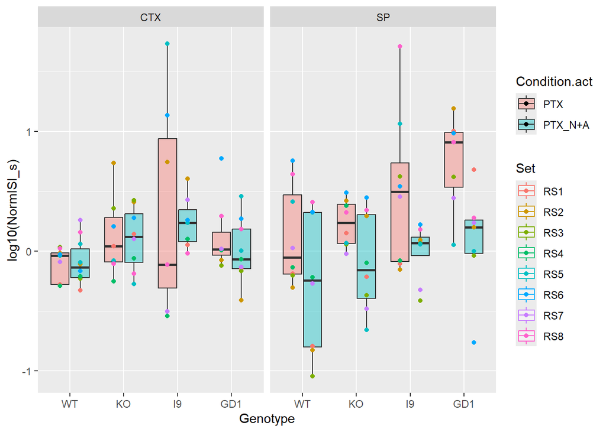

```r
col <- c("Set", "Genotype", "Brainregion")
df.merged <- merge(subset(df.burst, Condition == "BASE"), subset(df.burst, Condition != "BASE"), by=col, suffixes = c(".base", ".act"))


df.merged$NormBurstFrq <- df.merged$Burst_Peak_frequency.act / df.merged$Burst_Peak_frequency.base
df.merged$NormISI_s <- df.merged$isi_s.act / df.merged$isi_s.base


ggplot(df.merged, aes(x=Genotype, y=log10(NormISI_s), color=Set, fill=Condition.act, group=interaction(Genotype, Condition.act))) + geom_boxplot(alpha=0.4) + geom_point(position=position_jitterdodge(0)) + facet_grid(.~Brainregion, scales="free")
```

```r
mod <- lmer(log10(NormISI_s) ~ Genotype * Condition.act * Brainregion + (1|Set), subset(df.merged, Genotype %in% c("I9", "GD1")))
summary(mod)
```

```
## Linear mixed model fit by REML. t-tests use Satterthwaite's method [
## lmerModLmerTest]
## Formula: log10(NormISI_s) ~ Genotype * Condition.act * Brainregion + (1 |
##     Set)
##    Data: subset(df.merged, Genotype %in% c("I9", "GD1"))
##
## REML criterion at convergence: 85.1
##
## Scaled residuals:
##      Min       1Q   Median       3Q      Max
## -1.87021 -0.47365 -0.05438  0.40545  2.93961
##
## Random effects:
##  Groups   Name        Variance Std.Dev.
##  Set      (Intercept) 0.004913 0.07009
##  Residual             0.216342 0.46513
## Number of obs: 60, groups:  Set, 8
##
## Fixed effects:
##                                                Estimate Std. Error       df
## (Intercept)                                     0.33186    0.17776 51.88235
## GenotypeGD1                                    -0.19702    0.24897 46.18520
## Condition.actPTX_N+A                           -0.09653    0.24862 44.64096
## BrainregionSP                                   0.17536    0.24089 45.39746
## GenotypeGD1:Condition.actPTX_N+A               -0.04289    0.34204 45.74054
## GenotypeGD1:BrainregionSP                       0.42918    0.34643 45.79980
## Condition.actPTX_N+A:BrainregionSP             -0.41710    0.34044 44.64096
## GenotypeGD1:Condition.actPTX_N+A:BrainregionSP -0.10305    0.48259 45.19943
##                                                t value Pr(>|t|)
## (Intercept)                                      1.867   0.0676 .
## GenotypeGD1                                     -0.791   0.4328
## Condition.actPTX_N+A                            -0.388   0.6997
## BrainregionSP                                    0.728   0.4704
## GenotypeGD1:Condition.actPTX_N+A                -0.125   0.9008
## GenotypeGD1:BrainregionSP                        1.239   0.2217
## Condition.actPTX_N+A:BrainregionSP              -1.225   0.2269
## GenotypeGD1:Condition.actPTX_N+A:BrainregionSP  -0.214   0.8319
## ---
## Signif. codes:  0 '***' 0.001 '**' 0.01 '*' 0.05 '.' 0.1 ' ' 1
##
## Correlation of Fixed Effects:
##                 (Intr) GntGD1 Cn.PTX_N+A BrnrSP GnGD1:C.PTX_N+A GGD1:B
## GenotypeGD1     -0.700
## Cnd.PTX_N+A     -0.699  0.499
## BrainregnSP     -0.724  0.517  0.516
## GnGD1:C.PTX_N+A  0.509 -0.728 -0.727     -0.375
## GntyGD1:BSP      0.503 -0.719 -0.359     -0.695  0.523
## C.PTX_N+A:B      0.511 -0.365 -0.730     -0.707  0.531           0.491
## GGD1:C.PTX_N+A: -0.361  0.516  0.515      0.499 -0.709          -0.717
##                 C.PTX_N+A:
## GenotypeGD1
## Cnd.PTX_N+A
## BrainregnSP
## GnGD1:C.PTX_N+A
## GntyGD1:BSP
## C.PTX_N+A:B
## GGD1:C.PTX_N+A: -0.705
```

```r
emmeans(mod, pairwise ~ Condition.act | Genotype | Brainregion)
```

```
## $emmeans
## Genotype = I9, Brainregion = CTX:
##  Condition.act   emmean    SE   df lower.CL upper.CL
##  PTX            0.33186 0.178 51.9  -0.0263    0.690
##  PTX_N+A        0.23533 0.178 51.9  -0.1228    0.593
##
## Genotype = GD1, Brainregion = CTX:
##  Condition.act   emmean    SE   df lower.CL upper.CL
##  PTX            0.13483 0.179 51.9  -0.2235    0.493
##  PTX_N+A       -0.00459 0.158 50.9  -0.3212    0.312
##
## Genotype = I9, Brainregion = SP:
##  Condition.act   emmean    SE   df lower.CL upper.CL
##  PTX            0.50722 0.166 51.8   0.1735    0.841
##  PTX_N+A       -0.00641 0.166 51.8  -0.3401    0.327
##
## Genotype = GD1, Brainregion = SP:
##  Condition.act   emmean    SE   df lower.CL upper.CL
##  PTX            0.73937 0.178 51.9   0.3812    1.098
##  PTX_N+A        0.07981 0.178 51.9  -0.2783    0.438
##
## Degrees-of-freedom method: kenward-roger
## Results are given on the log10 (not the response) scale.
## Confidence level used: 0.95
##
## $contrasts
## Genotype = I9, Brainregion = CTX:
##  contrast        estimate    SE   df t.ratio p.value
##  PTX - (PTX_N+A)   0.0965 0.249 45.1   0.388  0.6996
##
## Genotype = GD1, Brainregion = CTX:
##  contrast        estimate    SE   df t.ratio p.value
##  PTX - (PTX_N+A)   0.1394 0.237 47.2   0.589  0.5590
##
## Genotype = I9, Brainregion = SP:
##  contrast        estimate    SE   df t.ratio p.value
##  PTX - (PTX_N+A)   0.5136 0.233 45.1   2.209  0.0323
##
## Genotype = GD1, Brainregion = SP:
##  contrast        estimate    SE   df t.ratio p.value
##  PTX - (PTX_N+A)   0.6596 0.249 45.1   2.653  0.0110
##
## Degrees-of-freedom method: kenward-roger
## Results are given on the log10 (not the response) scale.
```

```r
emmeans(mod, pairwise ~ Genotype | Condition.act | Brainregion)
```

```
## $emmeans
## Condition.act = PTX, Brainregion = CTX:
##  Genotype   emmean    SE   df lower.CL upper.CL
##  I9        0.33186 0.178 51.9  -0.0263    0.690
##  GD1       0.13483 0.179 51.9  -0.2235    0.493
##
## Condition.act = PTX_N+A, Brainregion = CTX:
##  Genotype   emmean    SE   df lower.CL upper.CL
##  I9        0.23533 0.178 51.9  -0.1228    0.593
##  GD1      -0.00459 0.158 50.9  -0.3212    0.312
##
## Condition.act = PTX, Brainregion = SP:
##  Genotype   emmean    SE   df lower.CL upper.CL
##  I9        0.50722 0.166 51.8   0.1735    0.841
##  GD1       0.73937 0.178 51.9   0.3812    1.098
##
## Condition.act = PTX_N+A, Brainregion = SP:
##  Genotype   emmean    SE   df lower.CL upper.CL
##  I9       -0.00641 0.166 51.8  -0.3401    0.327
##  GD1       0.07981 0.178 51.9  -0.2783    0.438
##
## Degrees-of-freedom method: kenward-roger
## Results are given on the log10 (not the response) scale.
## Confidence level used: 0.95
##
## $contrasts
## Condition.act = PTX, Brainregion = CTX:
##  contrast estimate    SE   df t.ratio p.value
##  I9 - GD1   0.1970 0.250 46.5   0.787  0.4351
##
## Condition.act = PTX_N+A, Brainregion = CTX:
##  contrast estimate    SE   df t.ratio p.value
##  I9 - GD1   0.2399 0.235 46.1   1.019  0.3135
##
## Condition.act = PTX, Brainregion = SP:
##  contrast estimate    SE   df t.ratio p.value
##  I9 - GD1  -0.2322 0.241 45.8  -0.962  0.3413
##
## Condition.act = PTX_N+A, Brainregion = SP:
##  contrast estimate    SE   df t.ratio p.value
##  I9 - GD1  -0.0862 0.241 45.8  -0.357  0.7226
##
## Degrees-of-freedom method: kenward-roger
## Results are given on the log10 (not the response) scale.
```

```r
mod <- lmer(log10(NormISI_s) ~ Genotype * Condition.act * Brainregion + (1|Set), subset(df.merged, Genotype %in% c("WT", "KO")))
summary(mod)
```

```
## Linear mixed model fit by REML. t-tests use Satterthwaite's method [
## lmerModLmerTest]
## Formula: log10(NormISI_s) ~ Genotype * Condition.act * Brainregion + (1 |
##     Set)
##    Data: subset(df.merged, Genotype %in% c("WT", "KO"))
##
## REML criterion at convergence: 53.5
##
## Scaled residuals:
##      Min       1Q   Median       3Q      Max
## -2.25803 -0.56332  0.00547  0.50650  1.91360
##
## Random effects:
##  Groups   Name        Variance Std.Dev.
##  Set      (Intercept) 0.01621  0.1273
##  Residual             0.09949  0.3154
## Number of obs: 66, groups:  Set, 8
##
## Fixed effects:
##                                                Estimate Std. Error        df
## (Intercept)                                   -0.093417   0.114673 47.707046
## GenotypeKO                                     0.218625   0.159513 51.658158
## Condition.actPTX_N+A                           0.008397   0.145138 51.332571
## BrainregionSP                                  0.218653   0.153493 51.325633
## GenotypeKO:Condition.actPTX_N+A               -0.030007   0.218800 51.484782
## GenotypeKO:BrainregionSP                      -0.111436   0.224317 51.397277
## Condition.actPTX_N+A:BrainregionSP            -0.396617   0.214333 51.221548
## GenotypeKO:Condition.actPTX_N+A:BrainregionSP  0.092648   0.312444 51.303232
##                                               t value Pr(>|t|)
## (Intercept)                                    -0.815    0.419
## GenotypeKO                                      1.371    0.176
## Condition.actPTX_N+A                            0.058    0.954
## BrainregionSP                                   1.425    0.160
## GenotypeKO:Condition.actPTX_N+A                -0.137    0.891
## GenotypeKO:BrainregionSP                       -0.497    0.621
## Condition.actPTX_N+A:BrainregionSP             -1.850    0.070 .
## GenotypeKO:Condition.actPTX_N+A:BrainregionSP   0.297    0.768
## ---
## Signif. codes:  0 '***' 0.001 '**' 0.01 '*' 0.05 '.' 0.1 ' ' 1
##
## Correlation of Fixed Effects:
##                (Intr) GntyKO Cn.PTX_N+A BrnrSP GnKO:C.PTX_N+A GKO:BS C.PTX_N+A:
## GenotypeKO     -0.607
## Cnd.PTX_N+A    -0.665  0.479
## BrainregnSP    -0.632  0.454  0.497
## GnKO:C.PTX_N+A  0.441 -0.728 -0.664     -0.329
## GntypKO:BSP     0.432 -0.711 -0.340     -0.684  0.518
## C.PTX_N+A:B     0.450 -0.324 -0.677     -0.715  0.449          0.489
## GKO:C.PTX_N+A: -0.309  0.510  0.465      0.490 -0.700         -0.718 -0.686
```

```r
emmeans(mod, pairwise ~ Condition.act | Genotype | Brainregion)
```

```
## $emmeans
## Genotype = WT, Brainregion = CTX:
##  Condition.act  emmean    SE   df lower.CL upper.CL
##  PTX           -0.0934 0.115 47.5 -0.32432   0.1375
##  PTX_N+A       -0.0850 0.110 44.5 -0.30685   0.1368
##
## Genotype = KO, Brainregion = CTX:
##  Condition.act  emmean    SE   df lower.CL upper.CL
##  PTX            0.1252 0.128 52.8 -0.13201   0.3824
##  PTX_N+A        0.1036 0.120 50.6 -0.13789   0.3451
##
## Genotype = WT, Brainregion = SP:
##  Condition.act  emmean    SE   df lower.CL upper.CL
##  PTX            0.1252 0.120 50.6 -0.11625   0.3667
##  PTX_N+A       -0.2630 0.120 50.6 -0.50447  -0.0215
##
## Genotype = KO, Brainregion = SP:
##  Condition.act  emmean    SE   df lower.CL upper.CL
##  PTX            0.2324 0.120 50.6 -0.00906   0.4739
##  PTX_N+A       -0.0932 0.120 50.6 -0.33464   0.1483
##
## Degrees-of-freedom method: kenward-roger
## Results are given on the log10 (not the response) scale.
## Confidence level used: 0.95
##
## $contrasts
## Genotype = WT, Brainregion = CTX:
##  contrast        estimate    SE   df t.ratio p.value
##  PTX - (PTX_N+A)  -0.0084 0.145 51.2  -0.058  0.9541
##
## Genotype = KO, Brainregion = CTX:
##  contrast        estimate    SE   df t.ratio p.value
##  PTX - (PTX_N+A)   0.0216 0.164 51.4   0.132  0.8956
##
## Genotype = WT, Brainregion = SP:
##  contrast        estimate    SE   df t.ratio p.value
##  PTX - (PTX_N+A)   0.3882 0.158 51.0   2.462  0.0173
##
## Genotype = KO, Brainregion = SP:
##  contrast        estimate    SE   df t.ratio p.value
##  PTX - (PTX_N+A)   0.3256 0.158 51.0   2.064  0.0441
##
## Degrees-of-freedom method: kenward-roger
## Results are given on the log10 (not the response) scale.
```

```r
emmeans(mod, pairwise ~ Genotype | Condition.act | Brainregion)
```

```
## $emmeans
## Condition.act = PTX, Brainregion = CTX:
##  Genotype  emmean    SE   df lower.CL upper.CL
##  WT       -0.0934 0.115 47.5 -0.32432   0.1375
##  KO        0.1252 0.128 52.8 -0.13201   0.3824
##
## Condition.act = PTX_N+A, Brainregion = CTX:
##  Genotype  emmean    SE   df lower.CL upper.CL
##  WT       -0.0850 0.110 44.5 -0.30685   0.1368
##  KO        0.1036 0.120 50.6 -0.13789   0.3451
##
## Condition.act = PTX, Brainregion = SP:
##  Genotype  emmean    SE   df lower.CL upper.CL
##  WT        0.1252 0.120 50.6 -0.11625   0.3667
##  KO        0.2324 0.120 50.6 -0.00906   0.4739
##
## Condition.act = PTX_N+A, Brainregion = SP:
##  Genotype  emmean    SE   df lower.CL upper.CL
##  WT       -0.2630 0.120 50.6 -0.50447  -0.0215
##  KO       -0.0932 0.120 50.6 -0.33464   0.1483
##
## Degrees-of-freedom method: kenward-roger
## Results are given on the log10 (not the response) scale.
## Confidence level used: 0.95
##
## $contrasts
## Condition.act = PTX, Brainregion = CTX:
##  contrast estimate    SE   df t.ratio p.value
##  WT - KO    -0.219 0.160 51.5  -1.368  0.1772
##
## Condition.act = PTX_N+A, Brainregion = CTX:
##  contrast estimate    SE   df t.ratio p.value
##  WT - KO    -0.189 0.150 51.3  -1.257  0.2146
##
## Condition.act = PTX, Brainregion = SP:
##  contrast estimate    SE   df t.ratio p.value
##  WT - KO    -0.107 0.158 51.0  -0.680  0.4998
##
## Condition.act = PTX_N+A, Brainregion = SP:
##  contrast estimate    SE   df t.ratio p.value
##  WT - KO    -0.170 0.158 51.0  -1.077  0.2866
##
## Degrees-of-freedom method: kenward-roger
## Results are given on the log10 (not the response) scale.
```

```r
mod <- lmer(log10(NormBurstFrq) ~ Genotype * Condition.act * Brainregion + (1|Set), subset(df.merged))
summary(mod)
```

```
## Linear mixed model fit by REML. t-tests use Satterthwaite's method [
## lmerModLmerTest]
## Formula: log10(NormBurstFrq) ~ Genotype * Condition.act * Brainregion +
##     (1 | Set)
##    Data: subset(df.merged)
##
## REML criterion at convergence: 227.7
##
## Scaled residuals:
##      Min       1Q   Median       3Q      Max
## -2.70989 -0.43754 -0.00998  0.42538  2.66539
##
## Random effects:
##  Groups   Name        Variance Std.Dev.
##  Set      (Intercept) 0.04937  0.2222
##  Residual             0.31809  0.5640
## Number of obs: 126, groups:  Set, 8
##
## Fixed effects:
##                                                  Estimate Std. Error         df
## (Intercept)                                      0.056710   0.204102  82.031139
## GenotypeKO                                       0.100667   0.284849 103.767297
## GenotypeI9                                       0.970480   0.284866 103.787188
## GenotypeGD1                                      0.159412   0.284827 103.743079
## Condition.actPTX_N+A                            -0.708967   0.259379 103.562427
## BrainregionSP                                    0.008896   0.274312 103.559603
## GenotypeKO:Condition.actPTX_N+A                  0.315341   0.390884 103.648507
## GenotypeI9:Condition.actPTX_N+A                 -0.358897   0.397692 103.480067
## GenotypeGD1:Condition.actPTX_N+A                -0.245370   0.384992 103.566473
## GenotypeKO:BrainregionSP                         0.324340   0.400825 103.595780
## GenotypeI9:BrainregionSP                        -0.305222   0.400837 103.605952
## GenotypeGD1:BrainregionSP                        0.269855   0.408338 103.785004
## Condition.actPTX_N+A:BrainregionSP              -0.225051   0.383143 103.484797
## GenotypeKO:Condition.actPTX_N+A:BrainregionSP   -0.060401   0.558420 103.531777
## GenotypeI9:Condition.actPTX_N+A:BrainregionSP    0.388414   0.563207 103.449390
## GenotypeGD1:Condition.actPTX_N+A:BrainregionSP   0.427082   0.564466 103.487678
##                                                t value Pr(>|t|)
## (Intercept)                                      0.278 0.781826
## GenotypeKO                                       0.353 0.724503
## GenotypeI9                                       3.407 0.000936 ***
## GenotypeGD1                                      0.560 0.576905
## Condition.actPTX_N+A                            -2.733 0.007375 **
## BrainregionSP                                    0.032 0.974193
## GenotypeKO:Condition.actPTX_N+A                  0.807 0.421665
## GenotypeI9:Condition.actPTX_N+A                 -0.902 0.368914
## GenotypeGD1:Condition.actPTX_N+A                -0.637 0.525311
## GenotypeKO:BrainregionSP                         0.809 0.420265
## GenotypeI9:BrainregionSP                        -0.761 0.448111
## GenotypeGD1:BrainregionSP                        0.661 0.510165
## Condition.actPTX_N+A:BrainregionSP              -0.587 0.558228
## GenotypeKO:Condition.actPTX_N+A:BrainregionSP   -0.108 0.914074
## GenotypeI9:Condition.actPTX_N+A:BrainregionSP    0.690 0.491960
## GenotypeGD1:Condition.actPTX_N+A:BrainregionSP   0.757 0.451001
## ---
## Signif. codes:  0 '***' 0.001 '**' 0.01 '*' 0.05 '.' 0.1 ' ' 1
```

```
##
## Correlation matrix not shown by default, as p = 16 > 12.
## Use print(x, correlation=TRUE)  or
##     vcov(x)        if you need it
```

```r
emmeans(mod, pairwise ~ Condition.act | Genotype | Brainregion)
```

```
## $emmeans
## Genotype = WT, Brainregion = CTX:
##  Condition.act  emmean    SE   df lower.CL upper.CL
##  PTX            0.0567 0.204 80.7  -0.3496    0.463
##  PTX_N+A       -0.6523 0.196 74.9  -1.0418   -0.263
##
## Genotype = KO, Brainregion = CTX:
##  Condition.act  emmean    SE   df lower.CL upper.CL
##  PTX            0.1574 0.228 92.3  -0.2953    0.610
##  PTX_N+A       -0.2362 0.214 86.7  -0.6622    0.190
##
## Genotype = I9, Brainregion = CTX:
##  Condition.act  emmean    SE   df lower.CL upper.CL
##  PTX            1.0272 0.228 92.3   0.5745    1.480
##  PTX_N+A       -0.0407 0.228 92.3  -0.4934    0.412
##
## Genotype = GD1, Brainregion = CTX:
##  Condition.act  emmean    SE   df lower.CL upper.CL
##  PTX            0.2161 0.228 92.4  -0.2364    0.669
##  PTX_N+A       -0.7382 0.204 80.6  -1.1446   -0.332
##
## Genotype = WT, Brainregion = SP:
##  Condition.act  emmean    SE   df lower.CL upper.CL
##  PTX            0.0656 0.214 86.7  -0.3604    0.492
##  PTX_N+A       -0.8684 0.214 86.7  -1.2944   -0.442
##
## Genotype = KO, Brainregion = SP:
##  Condition.act  emmean    SE   df lower.CL upper.CL
##  PTX            0.4906 0.214 86.7   0.0646    0.917
##  PTX_N+A       -0.1885 0.214 86.7  -0.6145    0.238
##
## Genotype = I9, Brainregion = SP:
##  Condition.act  emmean    SE   df lower.CL upper.CL
##  PTX            0.7309 0.214 86.7   0.3049    1.157
##  PTX_N+A       -0.1736 0.214 86.7  -0.5996    0.252
##
## Genotype = GD1, Brainregion = SP:
##  Condition.act  emmean    SE   df lower.CL upper.CL
##  PTX            0.4949 0.228 92.3   0.0422    0.948
##  PTX_N+A       -0.2574 0.228 92.3  -0.7102    0.195
```

[output cut: 25 more lines]

```
##
## Genotype = KO, Brainregion = SP:
##  contrast        estimate    SE  df t.ratio p.value
##  PTX - (PTX_N+A)    0.679 0.282 103   2.408  0.0178
##
## Genotype = I9, Brainregion = SP:
##  contrast        estimate    SE  df t.ratio p.value
##  PTX - (PTX_N+A)    0.905 0.282 103   3.208  0.0018
##
## Genotype = GD1, Brainregion = SP:
##  contrast        estimate    SE  df t.ratio p.value
##  PTX - (PTX_N+A)    0.752 0.301 103   2.495  0.0142
##
## Degrees-of-freedom method: kenward-roger
## Results are given on the log10 (not the response) scale.
```

```r
emmeans(mod, pairwise ~ Genotype | Condition.act | Brainregion)
```

```
## $emmeans
## Condition.act = PTX, Brainregion = CTX:
##  Genotype  emmean    SE   df lower.CL upper.CL
##  WT        0.0567 0.204 80.7  -0.3496    0.463
##  KO        0.1574 0.228 92.3  -0.2953    0.610
##  I9        1.0272 0.228 92.3   0.5745    1.480
##  GD1       0.2161 0.228 92.4  -0.2364    0.669
##
## Condition.act = PTX_N+A, Brainregion = CTX:
##  Genotype  emmean    SE   df lower.CL upper.CL
##  WT       -0.6523 0.196 74.9  -1.0418   -0.263
##  KO       -0.2362 0.214 86.7  -0.6622    0.190
##  I9       -0.0407 0.228 92.3  -0.4934    0.412
##  GD1      -0.7382 0.204 80.6  -1.1446   -0.332
##
## Condition.act = PTX, Brainregion = SP:
##  Genotype  emmean    SE   df lower.CL upper.CL
##  WT        0.0656 0.214 86.7  -0.3604    0.492
##  KO        0.4906 0.214 86.7   0.0646    0.917
##  I9        0.7309 0.214 86.7   0.3049    1.157
##  GD1       0.4949 0.228 92.3   0.0422    0.948
##
## Condition.act = PTX_N+A, Brainregion = SP:
##  Genotype  emmean    SE   df lower.CL upper.CL
##  WT       -0.8684 0.214 86.7  -1.2944   -0.442
##  KO       -0.1885 0.214 86.7  -0.6145    0.238
##  I9       -0.1736 0.214 86.7  -0.5996    0.252
##  GD1      -0.2574 0.228 92.3  -0.7102    0.195
##
## Degrees-of-freedom method: kenward-roger
## Results are given on the log10 (not the response) scale.
## Confidence level used: 0.95
##
## $contrasts
## Condition.act = PTX, Brainregion = CTX:
##  contrast estimate    SE  df t.ratio p.value
##  WT - KO  -0.10067 0.285 103  -0.353  0.9848
##  WT - I9  -0.97048 0.285 103  -3.405  0.0051
##  WT - GD1 -0.15941 0.285 103  -0.559  0.9438
##  KO - I9  -0.86981 0.303 104  -2.873  0.0251
```

[output cut: 18 more lines]

```
##  KO - GD1 -0.00426 0.292 103  -0.015  1.0000
##  I9 - GD1  0.23599 0.292 103   0.807  0.8511
##
## Condition.act = PTX_N+A, Brainregion = SP:
##  contrast estimate    SE  df t.ratio p.value
##  WT - KO  -0.67995 0.282 103  -2.411  0.0813
##  WT - I9  -0.69478 0.282 103  -2.464  0.0718
##  WT - GD1 -0.61098 0.292 103  -2.089  0.1636
##  KO - I9  -0.01483 0.282 103  -0.053  0.9999
##  KO - GD1  0.06897 0.292 103   0.236  0.9954
##  I9 - GD1  0.08380 0.292 103   0.286  0.9918
##
## Degrees-of-freedom method: kenward-roger
## Results are given on the log10 (not the response) scale.
## P value adjustment: tukey method for comparing a family of 4 estimates
```

```r
mod <- lmer(log10(NormBurstFrq) ~ Genotype * Condition.act * Brainregion + (1|Set), subset(df.merged))
summary(mod)
```

```
## Linear mixed model fit by REML. t-tests use Satterthwaite's method [
## lmerModLmerTest]
## Formula: log10(NormBurstFrq) ~ Genotype * Condition.act * Brainregion +
##     (1 | Set)
##    Data: subset(df.merged)
##
## REML criterion at convergence: 227.7
##
## Scaled residuals:
##      Min       1Q   Median       3Q      Max
## -2.70989 -0.43754 -0.00998  0.42538  2.66539
##
## Random effects:
##  Groups   Name        Variance Std.Dev.
##  Set      (Intercept) 0.04937  0.2222
##  Residual             0.31809  0.5640
## Number of obs: 126, groups:  Set, 8
##
## Fixed effects:
##                                                  Estimate Std. Error         df
## (Intercept)                                      0.056710   0.204102  82.031139
## GenotypeKO                                       0.100667   0.284849 103.767297
## GenotypeI9                                       0.970480   0.284866 103.787188
## GenotypeGD1                                      0.159412   0.284827 103.743079
## Condition.actPTX_N+A                            -0.708967   0.259379 103.562427
## BrainregionSP                                    0.008896   0.274312 103.559603
## GenotypeKO:Condition.actPTX_N+A                  0.315341   0.390884 103.648507
## GenotypeI9:Condition.actPTX_N+A                 -0.358897   0.397692 103.480067
## GenotypeGD1:Condition.actPTX_N+A                -0.245370   0.384992 103.566473
## GenotypeKO:BrainregionSP                         0.324340   0.400825 103.595780
## GenotypeI9:BrainregionSP                        -0.305222   0.400837 103.605952
## GenotypeGD1:BrainregionSP                        0.269855   0.408338 103.785004
## Condition.actPTX_N+A:BrainregionSP              -0.225051   0.383143 103.484797
## GenotypeKO:Condition.actPTX_N+A:BrainregionSP   -0.060401   0.558420 103.531777
## GenotypeI9:Condition.actPTX_N+A:BrainregionSP    0.388414   0.563207 103.449390
## GenotypeGD1:Condition.actPTX_N+A:BrainregionSP   0.427082   0.564466 103.487678
##                                                t value Pr(>|t|)
## (Intercept)                                      0.278 0.781826
## GenotypeKO                                       0.353 0.724503
## GenotypeI9                                       3.407 0.000936 ***
## GenotypeGD1                                      0.560 0.576905
## Condition.actPTX_N+A                            -2.733 0.007375 **
## BrainregionSP                                    0.032 0.974193
## GenotypeKO:Condition.actPTX_N+A                  0.807 0.421665
## GenotypeI9:Condition.actPTX_N+A                 -0.902 0.368914
## GenotypeGD1:Condition.actPTX_N+A                -0.637 0.525311
## GenotypeKO:BrainregionSP                         0.809 0.420265
## GenotypeI9:BrainregionSP                        -0.761 0.448111
## GenotypeGD1:BrainregionSP                        0.661 0.510165
## Condition.actPTX_N+A:BrainregionSP              -0.587 0.558228
## GenotypeKO:Condition.actPTX_N+A:BrainregionSP   -0.108 0.914074
## GenotypeI9:Condition.actPTX_N+A:BrainregionSP    0.690 0.491960
## GenotypeGD1:Condition.actPTX_N+A:BrainregionSP   0.757 0.451001
## ---
## Signif. codes:  0 '***' 0.001 '**' 0.01 '*' 0.05 '.' 0.1 ' ' 1
```

```
##
## Correlation matrix not shown by default, as p = 16 > 12.
## Use print(x, correlation=TRUE)  or
##     vcov(x)        if you need it
```

```r
emmeans(mod, pairwise ~ Condition.act | Genotype | Brainregion)
```

```
## $emmeans
## Genotype = WT, Brainregion = CTX:
##  Condition.act  emmean    SE   df lower.CL upper.CL
##  PTX            0.0567 0.204 80.7  -0.3496    0.463
##  PTX_N+A       -0.6523 0.196 74.9  -1.0418   -0.263
##
## Genotype = KO, Brainregion = CTX:
##  Condition.act  emmean    SE   df lower.CL upper.CL
##  PTX            0.1574 0.228 92.3  -0.2953    0.610
##  PTX_N+A       -0.2362 0.214 86.7  -0.6622    0.190
##
## Genotype = I9, Brainregion = CTX:
##  Condition.act  emmean    SE   df lower.CL upper.CL
##  PTX            1.0272 0.228 92.3   0.5745    1.480
##  PTX_N+A       -0.0407 0.228 92.3  -0.4934    0.412
##
## Genotype = GD1, Brainregion = CTX:
##  Condition.act  emmean    SE   df lower.CL upper.CL
##  PTX            0.2161 0.228 92.4  -0.2364    0.669
##  PTX_N+A       -0.7382 0.204 80.6  -1.1446   -0.332
##
## Genotype = WT, Brainregion = SP:
##  Condition.act  emmean    SE   df lower.CL upper.CL
##  PTX            0.0656 0.214 86.7  -0.3604    0.492
##  PTX_N+A       -0.8684 0.214 86.7  -1.2944   -0.442
##
## Genotype = KO, Brainregion = SP:
##  Condition.act  emmean    SE   df lower.CL upper.CL
##  PTX            0.4906 0.214 86.7   0.0646    0.917
##  PTX_N+A       -0.1885 0.214 86.7  -0.6145    0.238
##
## Genotype = I9, Brainregion = SP:
##  Condition.act  emmean    SE   df lower.CL upper.CL
##  PTX            0.7309 0.214 86.7   0.3049    1.157
##  PTX_N+A       -0.1736 0.214 86.7  -0.5996    0.252
##
## Genotype = GD1, Brainregion = SP:
##  Condition.act  emmean    SE   df lower.CL upper.CL
##  PTX            0.4949 0.228 92.3   0.0422    0.948
##  PTX_N+A       -0.2574 0.228 92.3  -0.7102    0.195
```

[output cut: 25 more lines]

```
##
## Genotype = KO, Brainregion = SP:
##  contrast        estimate    SE  df t.ratio p.value
##  PTX - (PTX_N+A)    0.679 0.282 103   2.408  0.0178
##
## Genotype = I9, Brainregion = SP:
##  contrast        estimate    SE  df t.ratio p.value
##  PTX - (PTX_N+A)    0.905 0.282 103   3.208  0.0018
##
## Genotype = GD1, Brainregion = SP:
##  contrast        estimate    SE  df t.ratio p.value
##  PTX - (PTX_N+A)    0.752 0.301 103   2.495  0.0142
##
## Degrees-of-freedom method: kenward-roger
## Results are given on the log10 (not the response) scale.
```

```r
emmeans(mod, pairwise ~ Genotype | Condition.act | Brainregion)
```

```
## $emmeans
## Condition.act = PTX, Brainregion = CTX:
##  Genotype  emmean    SE   df lower.CL upper.CL
##  WT        0.0567 0.204 80.7  -0.3496    0.463
##  KO        0.1574 0.228 92.3  -0.2953    0.610
##  I9        1.0272 0.228 92.3   0.5745    1.480
##  GD1       0.2161 0.228 92.4  -0.2364    0.669
##
## Condition.act = PTX_N+A, Brainregion = CTX:
##  Genotype  emmean    SE   df lower.CL upper.CL
##  WT       -0.6523 0.196 74.9  -1.0418   -0.263
##  KO       -0.2362 0.214 86.7  -0.6622    0.190
##  I9       -0.0407 0.228 92.3  -0.4934    0.412
##  GD1      -0.7382 0.204 80.6  -1.1446   -0.332
##
## Condition.act = PTX, Brainregion = SP:
##  Genotype  emmean    SE   df lower.CL upper.CL
##  WT        0.0656 0.214 86.7  -0.3604    0.492
##  KO        0.4906 0.214 86.7   0.0646    0.917
##  I9        0.7309 0.214 86.7   0.3049    1.157
##  GD1       0.4949 0.228 92.3   0.0422    0.948
##
## Condition.act = PTX_N+A, Brainregion = SP:
##  Genotype  emmean    SE   df lower.CL upper.CL
##  WT       -0.8684 0.214 86.7  -1.2944   -0.442
##  KO       -0.1885 0.214 86.7  -0.6145    0.238
##  I9       -0.1736 0.214 86.7  -0.5996    0.252
##  GD1      -0.2574 0.228 92.3  -0.7102    0.195
##
## Degrees-of-freedom method: kenward-roger
## Results are given on the log10 (not the response) scale.
## Confidence level used: 0.95
##
## $contrasts
## Condition.act = PTX, Brainregion = CTX:
##  contrast estimate    SE  df t.ratio p.value
##  WT - KO  -0.10067 0.285 103  -0.353  0.9848
##  WT - I9  -0.97048 0.285 103  -3.405  0.0051
##  WT - GD1 -0.15941 0.285 103  -0.559  0.9438
##  KO - I9  -0.86981 0.303 104  -2.873  0.0251
```

[output cut: 18 more lines]

```
##  KO - GD1 -0.00426 0.292 103  -0.015  1.0000
##  I9 - GD1  0.23599 0.292 103   0.807  0.8511
##
## Condition.act = PTX_N+A, Brainregion = SP:
##  contrast estimate    SE  df t.ratio p.value
##  WT - KO  -0.67995 0.282 103  -2.411  0.0813
##  WT - I9  -0.69478 0.282 103  -2.464  0.0718
##  WT - GD1 -0.61098 0.292 103  -2.089  0.1636
##  KO - I9  -0.01483 0.282 103  -0.053  0.9999
##  KO - GD1  0.06897 0.292 103   0.236  0.9954
##  I9 - GD1  0.08380 0.292 103   0.286  0.9918
##
## Degrees-of-freedom method: kenward-roger
## Results are given on the log10 (not the response) scale.
## P value adjustment: tukey method for comparing a family of 4 estimates
```

## Load and Clean up of Activity Level Analysis

Similar workflow as with burst level analysis, we can also look at individual spike (aka peaks) information such as amplitude and frequency.

Just be aware that frequency here is calculated per electrode and there is no information about other electrodes like with bursts.

The information extraction takes a while since we have so many peaks: - comment out the last line if you want to save some time

```r
wd_path <- "C:\\Users\\davec\\Documents\\R-Markdowns\\MEA_James\\MEA"

l_files <- list.files(path = wd_path ,pattern = "*.xlsx$", recursive = TRUE, full.names = TRUE)

l_files <- l_files[!grepl("SET", l_files) & !grepl("Jupyter", l_files) & !grepl("~", l_files)]

dfs <- lapply(l_files, function(x){
  as.data.frame(readxl::read_xlsx(x, sheet="Peak Level Analysis"))
})
names(dfs) <- l_files

df <- bind_rows(dfs, .id = "column_label")

#df <- df[df$Burst_Peak_frequency > 1,]

df.ag <- ag(df, cols= c("column_label", "File", "channel"))
```

```
##  [1] "...1"               "trace_index"        "event"
##  [4] "peak_index"         "peak_time_s"        "event_window_start"
##  [7] "event_window_end"   "Amplitude_mV"       "width_ms"
## [10] "inst_freq"          "isi_s"              "area"
```

```r
## Add information about recordings
df.ag.peak <- clean_table_mea(df.ag)
df.peak <- clean_table_mea(df)
```

## Plot a recording

subselect recordings otherwise ggplot will be overwhelmed

Here, I am plotting the baseline, PTX and PTX+NA of a particular recording side by side

I included also the information about the detected bursts frmo the previous analysis

Restricted to the first 60 sec. can extended but readibility will suffer.

I also included a filter for Burst_Peak_Frequency of 1hz.

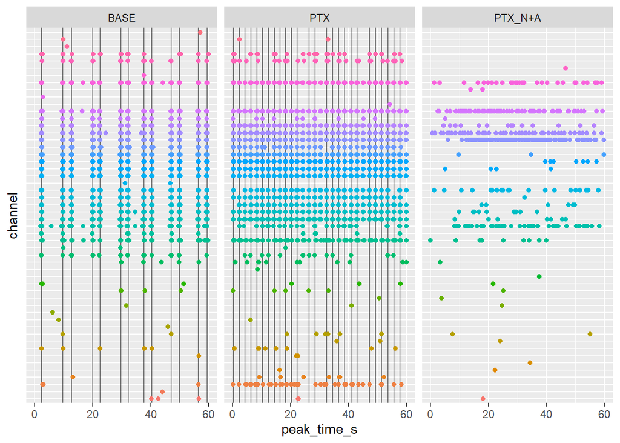

```r
id <- "RS1.WT.CTX"

stop_time <- 60
ggplot(subset(df.peak, Exp_ID == id & peak_time_s < stop_time), aes(x=peak_time_s, y=channel, color=channel)) + geom_vline(data=subset(df.burst.single, Exp_ID == id & Burst_Peak_frequency > 1 & 200*burst_time_s < stop_time), mapping=aes(xintercept =200* burst_time_s), alpha=0.5) + geom_point() +
  theme(axis.text.y=element_blank(),
        axis.ticks.y=element_blank()
        )  + guides(color = FALSE) + facet_grid(~Condition)
```

## Filter Channels without activity

Filter silent or noisy electrodes here.

```r
df.sum <- ag(df.peak, cols= c("column_label", "File", "channel"), fun=sum)
```

```
##  [1] "...1"               "trace_index"        "event"
##  [4] "peak_index"         "peak_time_s"        "event_window_start"
##  [7] "event_window_end"   "Amplitude_mV"       "width_ms"
## [10] "inst_freq"          "isi_s"              "area"
```

```r
cols<- c("column_label", "File", "channel", "event")
df.ag.peak <- merge(df.ag.peak, df.sum[,cols], by=c("column_label", "File", "channel"))


## set threshold here, you can also add more filters
threshold <- 5
df.ag.peak <- df.ag.peak[df.ag.peak$event.y > threshold,]


df.ag.peak <- ag(df.ag.peak, cols= c("column_label", "File"))
```

```
##  [1] "...1"               "trace_index"        "event.x"
##  [4] "peak_index"         "peak_time_s"        "event_window_start"
##  [7] "event_window_end"   "Amplitude_mV"       "width_ms"
## [10] "isi_s"              "area"               "event.y"
```

```r
df.ag.peak <- clean_table_mea(df.ag.peak)
```

## Plotting and statistics

Like above with burst level analysis

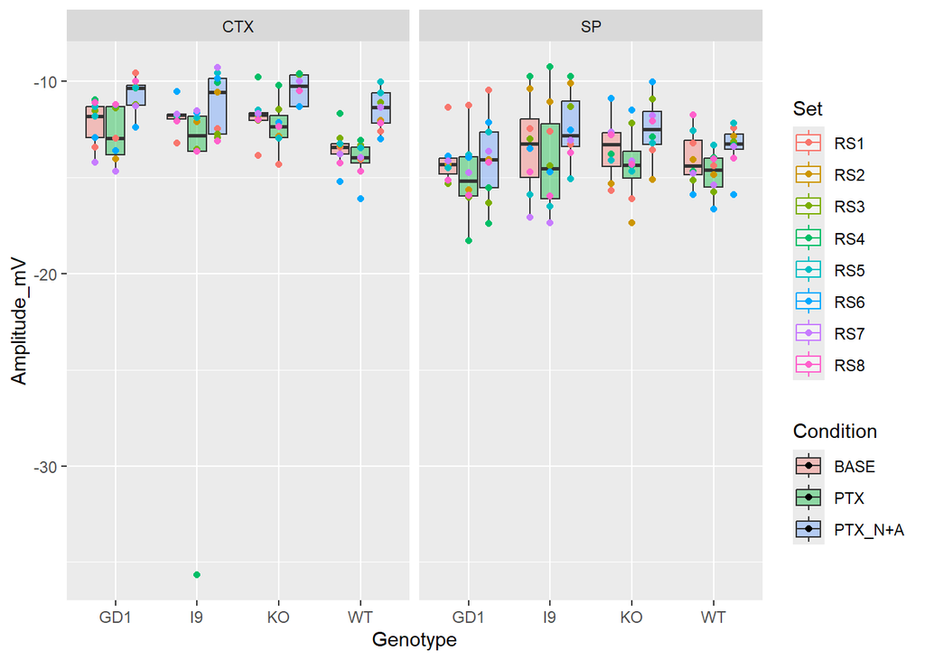

```r
ggplot(df.ag.peak, aes(x=Genotype, y=Amplitude_mV, color=Set, fill=Condition, group=interaction(Genotype, Condition))) + geom_boxplot(alpha=0.4) + geom_point(position=position_jitterdodge(0)) + facet_grid(.~Brainregion, scales="free")
```

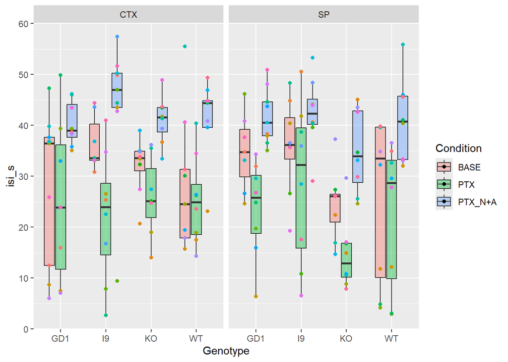

```r
ggplot(df.ag.peak, aes(x=Genotype, y=isi_s, color=Exp_ID, fill=Condition, group=interaction(Genotype, Condition))) + geom_boxplot(alpha=0.4) + geom_point(position=position_jitterdodge(0)) + facet_grid(.~Brainregion, scales="free") + guides(color=FALSE)
```

```r
df.ag.peak$Genotype <- factor(df.ag.peak$Genotype, levels= c("WT", "KO", "I9", "GD1"))
mod <- lmer(Amplitude_mV ~ Genotype * Condition * Brainregion + (1|Exp_ID), subset(df.ag.peak, Genotype %in% c("WT", "KO")))
summary(mod)
```

```
## Linear mixed model fit by REML. t-tests use Satterthwaite's method [
## lmerModLmerTest]
## Formula: Amplitude_mV ~ Genotype * Condition * Brainregion + (1 | Exp_ID)
##    Data: subset(df.ag.peak, Genotype %in% c("WT", "KO"))
##
## REML criterion at convergence: 241.9
##
## Scaled residuals:
##      Min       1Q   Median       3Q      Max
## -2.37197 -0.52666  0.05708  0.49226  2.66504
##
## Random effects:
##  Groups   Name        Variance Std.Dev.
##  Exp_ID   (Intercept) 1.31     1.1447
##  Residual             0.32     0.5657
## Number of obs: 97, groups:  Exp_ID, 32
##
## Fixed effects:
##                                           Estimate Std. Error       df t value
## (Intercept)                               -13.4466     0.4474  35.4673 -30.052
## GenotypeKO                                  1.6620     0.6356  36.0680   2.615
## ConditionPTX                               -0.6338     0.2764  57.1062  -2.293
## ConditionPTX_N+A                            1.9434     0.2702  57.2132   7.192
## BrainregionSP                              -0.5587     0.6356  36.0680  -0.879
## GenotypeKO:ConditionPTX                     0.1356     0.4058  57.2689   0.334
## GenotypeKO:ConditionPTX_N+A                -0.5674     0.3912  57.1134  -1.451
## GenotypeKO:BrainregionSP                   -1.1337     0.9009  36.3686  -1.258
## ConditionPTX:BrainregionSP                 -0.1483     0.3955  57.0633  -0.375
## ConditionPTX_N+A:BrainregionSP             -1.3267     0.3912  57.1134  -3.392
## GenotypeKO:ConditionPTX:BrainregionSP      -0.1975     0.5698  57.1474  -0.347
## GenotypeKO:ConditionPTX_N+A:BrainregionSP   0.9934     0.5595  57.0669   1.776
##                                           Pr(>|t|)
## (Intercept)                                < 2e-16 ***
## GenotypeKO                                 0.01295 *
## ConditionPTX                               0.02555 *
## ConditionPTX_N+A                          1.49e-09 ***
## BrainregionSP                              0.38525
## GenotypeKO:ConditionPTX                    0.73942
## GenotypeKO:ConditionPTX_N+A                0.15239
## GenotypeKO:BrainregionSP                   0.21625
```

[output cut: 17 more lines]

```
## CPTX_N+A:BS    0.209 -0.147 -0.338 -0.691    -0.308  0.230     0.477
## GKO:CPTX:BS   -0.143  0.211  0.485  0.237     0.211 -0.712    -0.343
## GKO:CPTX_N+A: -0.146  0.215  0.236  0.483     0.215 -0.337    -0.699
##               GKO:BS CPTX:B CPTX_N+A: GKO:CPTX:
## GenotypeKO
## ConditinPTX
## CndtPTX_N+A
## BrainregnSP
## GntyKO:CPTX
## GnKO:CPTX_N+A
## GntypKO:BSP
## CndtPTX:BSP    0.214
## CPTX_N+A:BS    0.217  0.495
## GKO:CPTX:BS   -0.305 -0.694 -0.343
## GKO:CPTX_N+A: -0.311 -0.346 -0.699     0.491
```

```r
emmeans(mod, trt.vs.ctrl ~ Condition | Genotype | Brainregion, ref="BASE")
```

```
## $emmeans
## Genotype = WT, Brainregion = CTX:
##  Condition emmean    SE   df lower.CL upper.CL
##  BASE       -13.4 0.447 35.4    -14.4   -12.54
##  PTX        -14.1 0.451 36.6    -15.0   -13.17
##  PTX_N+A    -11.5 0.447 35.4    -12.4   -10.60
##
## Genotype = KO, Brainregion = CTX:
##  Condition emmean    SE   df lower.CL upper.CL
##  BASE       -11.8 0.451 36.6    -12.7   -10.87
##  PTX        -12.3 0.461 39.2    -13.2   -11.35
##  PTX_N+A    -10.4 0.451 36.6    -11.3    -9.49
##
## Genotype = WT, Brainregion = SP:
##  Condition emmean    SE   df lower.CL upper.CL
##  BASE       -14.0 0.451 36.6    -14.9   -13.09
##  PTX        -14.8 0.451 36.6    -15.7   -13.87
##  PTX_N+A    -13.4 0.451 36.6    -14.3   -12.47
##
## Genotype = KO, Brainregion = SP:
##  Condition emmean    SE   df lower.CL upper.CL
##  BASE       -13.5 0.451 36.6    -14.4   -12.56
##  PTX        -14.3 0.451 36.6    -15.2   -13.41
##  PTX_N+A    -12.4 0.451 36.6    -13.3   -11.52
##
## Degrees-of-freedom method: kenward-roger
## Confidence level used: 0.95
##
## $contrasts
## Genotype = WT, Brainregion = CTX:
##  contrast         estimate    SE   df t.ratio p.value
##  PTX - BASE         -0.634 0.276 57.1  -2.293  0.0485
##  (PTX_N+A) - BASE    1.943 0.270 57.2   7.191  <.0001
##
## Genotype = KO, Brainregion = CTX:
##  contrast         estimate    SE   df t.ratio p.value
##  PTX - BASE         -0.498 0.297 57.4  -1.676  0.1781
##  (PTX_N+A) - BASE    1.376 0.283 57.0   4.865  <.0001
##
## Genotype = WT, Brainregion = SP:
##  contrast         estimate    SE   df t.ratio p.value
##  PTX - BASE         -0.782 0.283 57.0  -2.765  0.0148
##  (PTX_N+A) - BASE    0.617 0.283 57.0   2.181  0.0628
##
## Genotype = KO, Brainregion = SP:
##  contrast         estimate    SE   df t.ratio p.value
##  PTX - BASE         -0.844 0.283 57.0  -2.984  0.0081
##  (PTX_N+A) - BASE    1.043 0.283 57.0   3.687  0.0010
##
## Degrees-of-freedom method: kenward-roger
## P value adjustment: dunnettx method for 2 tests
```

```r
emmeans(mod, trt.vs.ctrl ~ Genotype | Condition | Brainregion, ref="WT")
```

```
## $emmeans
## Condition = BASE, Brainregion = CTX:
##  Genotype emmean    SE   df lower.CL upper.CL
##  WT        -13.4 0.447 35.4    -14.4   -12.54
##  KO        -11.8 0.451 36.6    -12.7   -10.87
##
## Condition = PTX, Brainregion = CTX:
##  Genotype emmean    SE   df lower.CL upper.CL
##  WT        -14.1 0.451 36.6    -15.0   -13.17
##  KO        -12.3 0.461 39.2    -13.2   -11.35
##
## Condition = PTX_N+A, Brainregion = CTX:
##  Genotype emmean    SE   df lower.CL upper.CL
##  WT        -11.5 0.447 35.4    -12.4   -10.60
##  KO        -10.4 0.451 36.6    -11.3    -9.49
##
## Condition = BASE, Brainregion = SP:
##  Genotype emmean    SE   df lower.CL upper.CL
##  WT        -14.0 0.451 36.6    -14.9   -13.09
##  KO        -13.5 0.451 36.6    -14.4   -12.56
##
## Condition = PTX, Brainregion = SP:
##  Genotype emmean    SE   df lower.CL upper.CL
##  WT        -14.8 0.451 36.6    -15.7   -13.87
##  KO        -14.3 0.451 36.6    -15.2   -13.41
##
## Condition = PTX_N+A, Brainregion = SP:
##  Genotype emmean    SE   df lower.CL upper.CL
##  WT        -13.4 0.451 36.6    -14.3   -12.47
##  KO        -12.4 0.451 36.6    -13.3   -11.52
##
## Degrees-of-freedom method: kenward-roger
## Confidence level used: 0.95
##
## $contrasts
## Condition = BASE, Brainregion = CTX:
##  contrast estimate    SE   df t.ratio p.value
##  KO - WT     1.662 0.636 36.0   2.615  0.0130
##
## Condition = PTX, Brainregion = CTX:
##  contrast estimate    SE   df t.ratio p.value
##  KO - WT     1.798 0.645 38.0   2.787  0.0083
##
## Condition = PTX_N+A, Brainregion = CTX:
##  contrast estimate    SE   df t.ratio p.value
##  KO - WT     1.095 0.636 36.0   1.722  0.0936
##
## Condition = BASE, Brainregion = SP:
##  contrast estimate    SE   df t.ratio p.value
##  KO - WT     0.528 0.638 36.6   0.827  0.4134
##
## Condition = PTX, Brainregion = SP:
##  contrast estimate    SE   df t.ratio p.value
##  KO - WT     0.466 0.638 36.6   0.730  0.4697
##
## Condition = PTX_N+A, Brainregion = SP:
##  contrast estimate    SE   df t.ratio p.value
##  KO - WT     0.954 0.638 36.6   1.495  0.1435
##
## Degrees-of-freedom method: kenward-roger
```

```r
mod <- lmer(log10(isi_s) ~ Genotype * Condition * Brainregion + (1|Exp_ID), subset(df.ag.peak, Genotype %in% c("I9", "GD1")))
summary(mod)
```

```
## Linear mixed model fit by REML. t-tests use Satterthwaite's method [
## lmerModLmerTest]
## Formula: log10(isi_s) ~ Genotype * Condition * Brainregion + (1 | Exp_ID)
##    Data: subset(df.ag.peak, Genotype %in% c("I9", "GD1"))
##
## REML criterion at convergence: 7.7
##
## Scaled residuals:
##     Min      1Q  Median      3Q     Max
## -3.4777 -0.3478  0.0249  0.6276  1.3785
##
## Random effects:
##  Groups   Name        Variance Std.Dev.
##  Exp_ID   (Intercept) 0.01925  0.1387
##  Residual             0.03440  0.1855
## Number of obs: 96, groups:  Exp_ID, 32
##
## Fixed effects:
##                                             Estimate Std. Error        df
## (Intercept)                                 1.530246   0.086338 71.704529
## GenotypeGD1                                -0.186407   0.117318 67.070735
## ConditionPTX                               -0.294926   0.096683 56.904004
## ConditionPTX_N+A                            0.095590   0.095711 59.193968
## BrainregionSP                               0.009728   0.118995 69.286273
## GenotypeGD1:ConditionPTX                    0.269187   0.136045 58.033107
## GenotypeGD1:ConditionPTX_N+A                0.164126   0.131770 57.956841
## GenotypeGD1:BrainregionSP                   0.180521   0.167103 68.200143
## ConditionPTX:BrainregionSP                  0.131883   0.133965 56.415786
## ConditionPTX_N+A:BrainregionSP             -0.013774   0.133265 57.583187
## GenotypeGD1:ConditionPTX:BrainregionSP     -0.310617   0.190932 57.234445
## GenotypeGD1:ConditionPTX_N+A:BrainregionSP -0.163653   0.187411 57.767785
##                                            t value Pr(>|t|)
## (Intercept)                                 17.724  < 2e-16 ***
## GenotypeGD1                                 -1.589  0.11678
## ConditionPTX                                -3.050  0.00347 **
## ConditionPTX_N+A                             0.999  0.32199
## BrainregionSP                                0.082  0.93508
## GenotypeGD1:ConditionPTX                     1.979  0.05261 .
## GenotypeGD1:ConditionPTX_N+A                 1.246  0.21794
## GenotypeGD1:BrainregionSP                    1.080  0.28382
```

[output cut: 17 more lines]

```
## CPTX_N+A:BS     0.448 -0.330 -0.400 -0.718    -0.596  0.284      0.522
## GGD1:CPTX:B    -0.306  0.404  0.506  0.282     0.411 -0.713     -0.364
## GGD1:CPTX_N+A: -0.318  0.412  0.284  0.511     0.424 -0.359     -0.703
##                GGD1:B CPTX:B CPTX_N+A: GGD1:CPTX:
## GenotypeGD1
## ConditinPTX
## CndtPTX_N+A
## BrainregnSP
## GntGD1:CPTX
## GnGD1:CPTX_N+A
## GntyGD1:BSP
## CndtPTX:BSP     0.418
## CPTX_N+A:BS     0.424  0.529
## GGD1:CPTX:B    -0.577 -0.702 -0.371
## GGD1:CPTX_N+A: -0.591 -0.376 -0.711     0.520
```

```r
emmeans(mod, trt.vs.ctrl ~ Condition | Genotype | Brainregion, ref="BASE")
```

```
## $emmeans
## Genotype = I9, Brainregion = CTX:
##  Condition emmean     SE   df lower.CL upper.CL
##  BASE        1.53 0.0864 71.8     1.36     1.70
##  PTX         1.24 0.0819 66.6     1.07     1.40
##  PTX_N+A     1.63 0.0795 61.5     1.47     1.78
##
## Genotype = GD1, Brainregion = CTX:
##  Condition emmean     SE   df lower.CL upper.CL
##  BASE        1.34 0.0795 61.5     1.18     1.50
##  PTX         1.32 0.0864 71.8     1.15     1.49
##  PTX_N+A     1.60 0.0819 66.6     1.44     1.77
##
## Genotype = I9, Brainregion = SP:
##  Condition emmean     SE   df lower.CL upper.CL
##  BASE        1.54 0.0819 66.6     1.38     1.70
##  PTX         1.38 0.0819 66.6     1.21     1.54
##  PTX_N+A     1.62 0.0819 66.6     1.46     1.79
##
## Genotype = GD1, Brainregion = SP:
##  Condition emmean     SE   df lower.CL upper.CL
##  BASE        1.53 0.0864 71.8     1.36     1.71
##  PTX         1.33 0.0819 66.6     1.17     1.49
##  PTX_N+A     1.62 0.0795 61.5     1.46     1.78
##
## Degrees-of-freedom method: kenward-roger
## Results are given on the log10 (not the response) scale.
## Confidence level used: 0.95
##
## $contrasts
## Genotype = I9, Brainregion = CTX:
##  contrast         estimate     SE   df t.ratio p.value
##  PTX - BASE        -0.2949 0.0968 57.0  -3.048  0.0068
##  (PTX_N+A) - BASE   0.0956 0.0960 59.3   0.996  0.5114
##
## Genotype = GD1, Brainregion = CTX:
##  contrast         estimate     SE   df t.ratio p.value
##  PTX - BASE        -0.0257 0.0960 59.3  -0.268  0.9368
##  (PTX_N+A) - BASE   0.2597 0.0906 56.7   2.866  0.0113
##
## Genotype = I9, Brainregion = SP:
##  contrast         estimate     SE   df t.ratio p.value
##  PTX - BASE        -0.1630 0.0927 56.0  -1.758  0.1527
##  (PTX_N+A) - BASE   0.0818 0.0927 56.0   0.882  0.5837
##
## Genotype = GD1, Brainregion = SP:
##  contrast         estimate     SE   df t.ratio p.value
##  PTX - BASE        -0.2045 0.0968 57.0  -2.113  0.0731
##  (PTX_N+A) - BASE   0.0823 0.0960 59.3   0.857  0.5997
##
## Degrees-of-freedom method: kenward-roger
## Results are given on the log10 (not the response) scale.
## P value adjustment: dunnettx method for 2 tests
```

```r
emmeans(mod, trt.vs.ctrl ~ Genotype | Condition | Brainregion, ref="I9")
```

```
## $emmeans
## Condition = BASE, Brainregion = CTX:
##  Genotype emmean     SE   df lower.CL upper.CL
##  I9         1.53 0.0864 71.8     1.36     1.70
##  GD1        1.34 0.0795 61.5     1.18     1.50
##
## Condition = PTX, Brainregion = CTX:
##  Genotype emmean     SE   df lower.CL upper.CL
##  I9         1.24 0.0819 66.6     1.07     1.40
##  GD1        1.32 0.0864 71.8     1.15     1.49
##
## Condition = PTX_N+A, Brainregion = CTX:
##  Genotype emmean     SE   df lower.CL upper.CL
##  I9         1.63 0.0795 61.5     1.47     1.78
##  GD1        1.60 0.0819 66.6     1.44     1.77
##
## Condition = BASE, Brainregion = SP:
##  Genotype emmean     SE   df lower.CL upper.CL
##  I9         1.54 0.0819 66.6     1.38     1.70
##  GD1        1.53 0.0864 71.8     1.36     1.71
##
## Condition = PTX, Brainregion = SP:
##  Genotype emmean     SE   df lower.CL upper.CL
##  I9         1.38 0.0819 66.6     1.21     1.54
##  GD1        1.33 0.0819 66.6     1.17     1.49
##
## Condition = PTX_N+A, Brainregion = SP:
##  Genotype emmean     SE   df lower.CL upper.CL
##  I9         1.62 0.0819 66.6     1.46     1.79
##  GD1        1.62 0.0795 61.5     1.46     1.78
##
## Degrees-of-freedom method: kenward-roger
## Results are given on the log10 (not the response) scale.
## Confidence level used: 0.95
##
## $contrasts
## Condition = BASE, Brainregion = CTX:
##  contrast estimate    SE   df t.ratio p.value
##  GD1 - I9 -0.18641 0.117 67.2  -1.587  0.1171
##
## Condition = PTX, Brainregion = CTX:
##  contrast estimate    SE   df t.ratio p.value
##  GD1 - I9  0.08278 0.119 69.4   0.695  0.4892
##
## Condition = PTX_N+A, Brainregion = CTX:
##  contrast estimate    SE   df t.ratio p.value
##  GD1 - I9 -0.02228 0.114 64.1  -0.195  0.8458
##
## Condition = BASE, Brainregion = SP:
##  contrast estimate    SE   df t.ratio p.value
##  GD1 - I9 -0.00589 0.119 69.4  -0.049  0.9607
##
## Condition = PTX, Brainregion = SP:
##  contrast estimate    SE   df t.ratio p.value
##  GD1 - I9 -0.04732 0.116 66.6  -0.409  0.6842
##
## Condition = PTX_N+A, Brainregion = SP:
##  contrast estimate    SE   df t.ratio p.value
##  GD1 - I9 -0.00541 0.114 64.1  -0.047  0.9623
##
## Degrees-of-freedom method: kenward-roger
## Results are given on the log10 (not the response) scale.
```

## To Save images

Set your plot of interest as a variable and use the function ggsave including location of saving

Example:

```r
p2save <- ggplot(df.ag.peak, aes(x=Genotype, y=Amplitude_mV, color=Set, fill=Condition, group=interaction(Genotype, Condition))) + geom_boxplot(alpha=0.4) + geom_point(position=position_jitterdodge(0)) + facet_grid(.~Brainregion, scales="free")


ggsave("C:\\Users\\davec\\Documents\\R-Markdowns\\MEA_James\\MEA\\Amplitudes.png", plot = p2save)
```

ggplots can be customized a lot to your liking. Let me know if you want something specific.